# 智能制造系统设计 · 第 9 讲：工程与社会与工程伦理（二）风险、安全与责任，工程师与组织

刘训臣

山东科技大学 机械电子工程学院

# 第〇部分 · 课程介绍与本讲定位

- 教学内容与主线：风险来源 → 事故定性 → 工程师与组织 → 文化与信任
- 本讲回答第 8 讲留下的问题：**为什么组织会压过工程判断**
- 案例以中国现场为主：甬温线、凤凰沱江大桥、锅炉爆炸、吊装事故
- 落点：把“责任”从个人道德，扩展为**可设计的组织机制**

## 第 9 讲：教学内容与主线（一）

**内容块 1 · 工程风险与评估**

- 风险来源三分法：技术因素、人为因素、外部环境
- 技术防护的逻辑：锅炉三大安全附件、压力容器与管道
- 人为因素的七个真实案例；外部环境的长期代价
- 风险评估方法 FTA／ETA 与它的四条局限

**内容块 2 · 安全事故 vs 安全责任事故**

- 两个概念的本质区别：是否存在应尽而未尽的注意义务
- 判定的四个关键问题与领导责任的五种情形
- 案例：甬温线 7·23、凤凰沱江大桥、锅炉爆炸
- 建设工程安全生产管理条例：五方主体责任与关键条款

## 第 9 讲：教学内容与主线（二）

**内容块 3 · 工程师与组织**

- 工程师与管理者的职业矛盾与交流矛盾
- 功能性理性：组织目标如何改写技术问题
- 责任模糊化的六种表现
- 吹哨人的三个条件与两个准备

**内容块 4 · 健康组织文化与信任**

- 健康组织文化八条：让坏消息能上来
- 信任的构成：能力、诚实、善意
- 信任的建立与修复：从记录到制度改造
- 从组织到个人的责任地图

## 教学进度 · 10 次课全览

| 次 | 模块 | 主题 |
| --- | --- | --- |
| 1 | 导论与 3.1 | 课程导论、工程与社会与质量工程（一）：国家战略、工程的社会属性、质量管理基础 |
| 2 | 3.1 | 质量工程（二）与质量工具：五大工具 APQP／FMEA／MSA／SPC／PPAP、CPK、QC 七大手法 |
| 3 | 3.2 | 工业工程与精益生产（＋实验 2 课时：线性规划与工业工程例子） |
| 4 | 3.3、3.4 | 安全工程与环保工程：海因里希法则、事故树 FTA、风险评估、三废治理、双碳 |
| 5 | 3.5、3.6 | 成本管理与人力资源：成本构成、投资回收期、NPV／IRR、质量成本、人才与激励 |
| 6 | 4.1～4.3 | 企业信息系统（一）：ERP、MES、PLM 与系统集成全景 |
| 7 | 4、6 | 企业信息系统（二）与 8D：CRM／WMS／APS，8D 八步与软件开发流程 |
| 8 | 工程伦理（一） | 工程事故与伦理准则：凯悦酒店、NSPE 准则、伦理决策框架 |
| **9** | **工程伦理（二）** | **风险、安全与责任，工程师与组织：责任判定、组织文化与信任** |
| 10 | 伦理（三）与综合 | 技术的社会意义、国际化、AI 伦理；智能设计应用、前沿、课程设计与总复习 |

## 本讲在课程中的位置

**第 8 讲**回答了“工程师该怎么做”：准则给判据、框架给说理。

**第 9 讲**回答“为什么经常做不到”：

- 风险不止来自技术，也来自人和环境——所以不可能靠单一防线解决
- 事故定性决定责任分配，而责任分配依赖**证据**而非感觉
- 组织会用“功能性理性”把安全问题翻译成成本问题
- 组织文化决定坏消息能否上达，信任决定合作能否持续

> 一句话：**第 8 讲讲“应该”，第 9 讲讲“为什么做不到”，第 10 讲讲“怎么改”。**
- 工程与社会与工程伦理专题共 **6 课时**：本讲为伦理专题的**第 4–5 课时**（第 1 讲 1 ＋ 第 8 讲 2 ＋ 第 9 讲 2 ＋ 第 10 讲 1）

## 本讲的两个落点

**落点一：事故是可以被“定性”的**

- 安全事故与安全责任事故的区别不在后果大小，而在**注意义务是否缺失**
- 定性的四问：可预见吗？义务尽了吗？违章了吗？管理到位吗？
- 定性决定责任分配：行政责任、民事责任、刑事责任各不相同

**落点二：组织文化是可以被“设计”的**

- 责任模糊化的六种表现不是个人品质问题，而是**激励结构**问题
- 健康组织文化的八条，每一条都能落到具体制度（渠道、时限、第三方、记录）
- 信任不是靠人品，而是靠**可核查的记录与履约**累积

## 本讲 90 分钟怎么安排：六块时间账

> **六块时间 6＋24＋16＋24＋16＋4＝90 分钟：两个 24 分钟是全场重心。**

| 序 | 时间块 | 讲什么 | 分钟 |
| --- | --- | --- | --- |
| 0 | 开场与回顾 | 六问、目标、路线图 | 6 |
| 1 | 工程风险与评估 | 三分法、FTA 与可接受性 | 24 |
| 2 | 事故与责任定性 | 两个概念与判定四问 | 16 |
| 3 | 工程师与组织 | 责任模糊化与吹哨 | 24 |
| 4 | 文化与信任 | 八条、信任与修复 | 16 |
| 5 | 收尾 | 考法、小结、作业 | 4 |

- 两个 24 分钟是重心：风险怎么算、组织怎么失灵
- 16 分钟的事故定性最紧：只讲四问与两个案例，条例条款留自学
- 168 页 ÷ 90 分钟 ≈ 每页 32 秒：讲判据与事实链，不逐条念条文
- 先压：甬温线调度细节、凤凰桥施工细节、条例逐条
- 不能压：判定四问、责任模糊化六种、信任三要素

## 第 8 讲回顾与检查：六个问题

> **六问各 30 秒：答不出的那一条，就是今天要补的那一条。**

| 概念 | 一句话答案 | 今天怎么接 |
| --- | --- | --- |
| ① 工程社会性 | 工程是社会实验；三重职责、四维代价 | 风险与代价由谁承担 |
| ② 凯悦酒店 | 1981-07-17，114 死；吊杆一改二，荷载翻倍 | 变更如何变成事故链 |
| ③ 职业准则 | NSPE 六条，“公众安全至上”排第一 | 判定“应尽义务”的文本依据 |
| ④ 吹哨 | 明显危害、内部渠道走尽、公开能止损 | 三条件在组织里为何难满足 |
| ⑤ 五框架 | 后果、义务、美德＋权利、关怀 | 组织失效用哪把尺量 |
| ⑥ 划线法 | 六特征两端定位，权重不等于计数 | 先找端点，再定权重 |

- 六问分三组：①② 事实与代价，③④ 判据与行动，⑤⑥ 工具与方法
- 抽查：合上讲义写关键词，随机点两人各答一问；答不出不扣分
- 最易错：凯悦不是“施工偷工”，是变更后荷载翻倍而复核缺位
- 一句提醒：第 8 讲讲“该不该”，本讲追问“为什么做不到”

## 本讲学习目标与能力清单

> **四条能力＝四个动作：会算、会判、会写、会决。**

| 能力 | 具体要求与落点 | 验收标准（可检查） |
| --- | --- | --- |
| 会算风险 | 风险＝概率×后果；FTA 割集、ETA 分支概率 | 给产线三个风险算期望值并排序 |
| 会判组织失效 | 功能性理性、责任模糊化、群体思维 | 指认三处制度缺口并给证据 |
| 会写风险沟通 | 两套风险语言、知情同意、信息公开 | 200 字通告：风险、备选、渠道 |
| 会做伦理决策 | 三框架、划线法、吹哨阶梯 | 300 字：结论、残余风险、责任人 |

- 四个动词：算、判、写、决；不要求背伦理学史与人名年代
- 16 分钟的事故定性并入“会判”：先判性质，再判缺口
- 衔接：FMEA 练预见、8D 练闭环，本讲练“谁负责、怎么改”
- 验收写成当场能做的动作，不写“理解”“掌握”
- 作业即课程设计伦理章底稿：选一个智能制造场景

## 风险与组织在智能制造中的位置

> **智能制造没有消灭风险，只是把风险从“人手”挪到“接口”。**

| 层级 | 典型对象 | 伦理问题 | 本讲接口 |
| --- | --- | --- | --- |
| 设备层 | 锅炉压力容器、安全仪表 | 附件失效、检验缺失 | 风险三分法与 FTA |
| 算法层 | 预测性维护、AI 质检 | 误判谁负责、数据偏见 | 责任判定与知情同意 |
| 组织层 | MES／PLM 变更、KPI | 坏消息上不来、责任模糊 | 功能性理性、文化八条 |

- 设备层看“防护是否独立”：安全仪表应与基本控制分开
- 算法层看“责任是否留痕”：模型版本、训练数据、复核记录可追溯
- 组织层看“坏消息有没有路”：上报若被 KPI 惩罚，数据一定失真
- 三层不并列：设备缺陷常由组织决策埋下，算法误判常被数据治理放大
- 一句话：技术越自动，责任越要写清楚

## 考试视角：本讲伦理怎么考、占多少分

> **六卷没有一道纯伦理题；与本讲相关的内容以 3＋10＋10 分三种形态入卷。**

| 考查形态 | 分值 | 六卷实况（2020 至 2022） | 怎么准备 |
| --- | --- | --- | --- |
| 单选·责任 | 3 分 | 六卷各 1 题考“无限责任” | 分清个人独资与公司 |
| 事故树 | 10 分 | 六卷均考布尔化简、等效树 | 割集对应到责任点 |
| 鱼骨图 | 10 分 | 六卷均考人机料法环 | “人”“法”两支写管理原因 |
| 直接伦理题 | 0 分 | 六卷均未单独命题 | 不押题，但要写得出 |

- 卷面：单选 30＋简答 30＋三大题 30＋计算 10，伦理无独立分值
- 可关联 23 分（3＋10＋10），但都不是本讲独有
- 简答常考 8D 五步：D4 真因、D7 预防再发即“组织整改”
- 预测题按 10 分估：给事故背景，问“谁该负责、依据是什么”
- 提醒：写“我认为”之前，先写事实与依据

## 本讲路线图与课前准备

> **一条主线：算清风险 → 判明性质 → 看见组织 → 修好制度。**

| 块 | 分钟 | 入口问题 | 出口 |
| --- | --- | --- | --- |
| 〇 开场 | 6 | 第 8 讲留下什么 | 六问过关、目标清楚 |
| 一 风险 | 24 | 风险能不能算准 | 会用公式与 FTA／ETA |
| 二 定性 | 16 | 事故还是责任事故 | 能用四问定性质 |
| 三 组织 | 24 | 真话为什么上不去 | 能指认责任模糊化 |
| 四 文化 | 16 | 什么样的组织值得信 | 能设计三条制度 |
| 五 收尾 | 4 | 带走什么 | 作业清楚、预告明确 |

- 每块都有出口动作：说清、算对、指认、写出
- 课前读：教材第 6 章（风险与责任）、第 7 章（工程师与组织）
- 必带：讲义、计算器、第 8 讲案例笔记
- 预习问题：安全仪表报警被屏蔽三个月，先查哪三样记录
- 纪律：案例的时间、伤亡、判定会进分析题，跟事实链，不抄 PPT

## 推导留给 AI：课程定位与本讲主线（汇总）

- 为什么“事故定性”要靠证据而不是靠后果？请用两个后果相同但定性不同的例子说明。
- 把“功能性理性”翻译成一个机械制造企业的具体决策场景，并给出工程师的介入点。
- 健康组织文化八条中，哪一条最容易“写在墙上但不执行”？为什么？
- 信任的修复为什么必须包含“制度改造”这一步？只道歉行不行？

## 产教融合 · 本讲企业真题：8D 为何写成“加强培训”

> **企业场景：**企业原 8D 的 D4 停在“操作工疏忽”，D5 写成“加强培训、加强巡检”，跨部门小组签字通过。

| 企业真实问题 | 本讲工具 | 学生产出 |
| --- | --- | --- |
| 责任界限被模糊、细节下压而功劳上移，组织让真话说不出来 | 功能性理性、健康组织文化八条、信任 | 组织改进建议（汇报机制、评审规则、责任人） |

- **教案对应：**第六章 8D、工程伦理（二）；**企业参与：**质量经理提供 8D 评审记录与组织架构
- **验收：**能识别至少 3 种责任模糊化手法；改进建议可落地、有责任人与时限。

# 第一部分 · 工程风险与评估

- 风险的定义（概率 × 后果的三种读法）与评估、管理、认知、沟通四维度闭环
- 风险来源三分法：技术因素、人为因素、外部环境；FTA 与 ETA 两类评估方法
- 技术防护与案例：锅炉爆炸、压力容器与管道、吊装、三门峡
- 正常事故、专家与公众的风险认知、知情同意与伦理评估

## 风险的定义：概率与后果的三种读法

- 工程定义：$R = P \times C$，即事件发生的概率乘后果的严重程度
- 读法一（期望值）：$R=\sum_i p_i c_i$，把全部后果谱系加权求和
- 例：泄漏概率 $10^{-2}$/年、后果 10 人伤亡，期望损失为 $0.1$ 人/年
- 读法二（频率）：$\mathrm{FAR} = N \times 10^{8} / H$，每亿工时死亡数，可跨行业比较
- 读法三（分布）：$F_N(n) = P(N \ge n)$，社会风险曲线，看“一次能死多少人”
- 三问三答：平均损失多少、职业有多危险、能否承受一次大事故
- 期望值的盲区：$10^{-7}$ 的概率配上万人后果，期望值只有 $10^{-3}$ 人/年
- 一句话：公式给的是排序工具，不是“可接受”的答案

## 风险来源（一）：技术因素

- **零部件老化**：疲劳、腐蚀、磨损、蠕变 → 对策：定期检验、寿命管理、备件更换
- **控制系统失灵**：传感器漂移、执行器卡涩、逻辑错误 → 对策：冗余、失效安全（fail-safe）、定期校验
- **非线性作用**：共振、颤振、热—力耦合、屈曲 → 对策：设计与试验覆盖、避开共振区
- 技术因素的特点：**可预测、可计算**，能用 FTA／FMEA 系统覆盖
- 但“可预测”不等于“已被预测”：凯悦的连接处、甬温线的列控中心，都属于技术因素被漏算或被掩盖
- 智能制造的新增技术因素：软件缺陷、网络攻击、算法漂移、数据质量

## 技术因素案例：锅炉三大安全附件

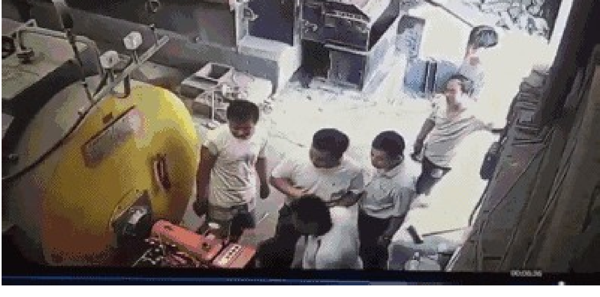

- 2016 年 5 月 12 日 10:15 许，上海奉贤区南奉公路 681 号一公司**锅炉爆炸**，**1 死 2 伤**
- 爆炸机理：受压元件超压 → 薄弱处破裂 → 锅内饱和水**瞬间汽化膨胀**（1/10～1/20 秒）→ 冲击波
- 三大安全附件：
  - **安全阀**：超压时泄放降压
  - **水位表**：直接反映锅内水位
  - **压力表**：直接反映运行压力
- 技术防护的逻辑：用**三个独立装置**挡住同一个失效模式（超压）

## 安全附件为什么必须定期校验

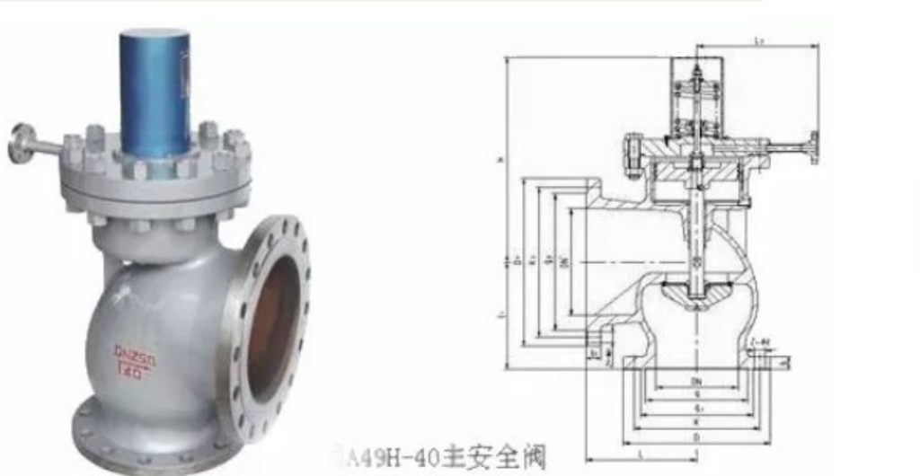

- **安全阀**：最重要安全装置之一；应定期整定，运行前手动排放或做功能试验——阀芯锈死、弹簧失效即**超压时打不开**
- **水位表**：直接显示锅内水位；连通管堵塞会造成**假水位** → 缺水或满水
- **压力表**：反映运行压力；要求**每半年校验一次**，确保灵敏可靠
- 三个附件的共同点：都是“**平时不用、用一次救命**”的装置——所以必须靠**定期校验**保持可用
- 管理落点：校验记录、铅封、整定压力台账；无记录即视为未校验

## 技术因素案例：压力容器与压力管道

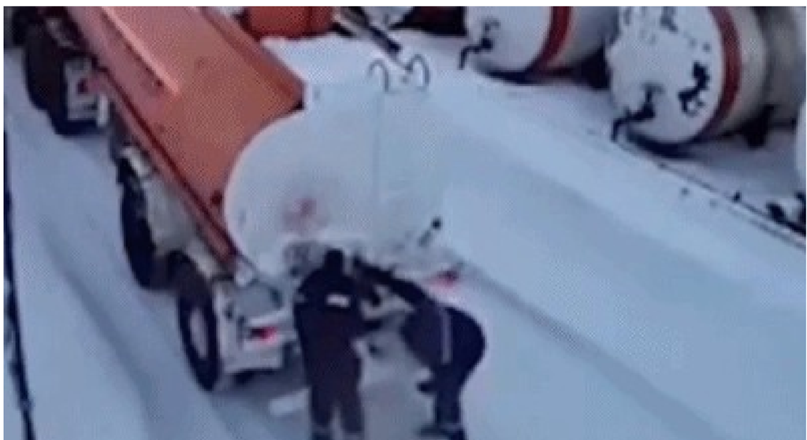

[figure not shown]

- **压力容器**：罐车罐体、储罐、反应器——承压 + 介质危险（易燃、有毒）
- **压力管道**：蒸汽、燃气、化工介质——长距离、隐蔽、易腐蚀
- 典型失效：超压、腐蚀减薄、焊缝缺陷、疲劳裂纹、阀门误操作
- 管理手段：年度检查与全面检验、安全阀校验、无损检测、介质腐蚀监测
- 失效后果被放大：压力能瞬间释放，形成冲击波、碎片与二次灾害

## 风险来源（二）：人为因素——七个“看手机”的案例

| 时间 | 场景 | 后果 | 直接原因 |
| --- | --- | --- | --- |
| 2020-03-22 | 京港澳高速沙井收费站 | 油罐车侧翻起火 | 司机频繁使用手机、低头看屏（前 10 分钟） |
| 2020-03-03 | 福建三明在建工地 | 1 人被吊钩砸死 | 吊车司机玩手机，忘下大钩，钢丝绳挣断 |
| 2019-04-30 | 贵阳万科理想城工地 | 塔吊倒塌，1 死 | 司机视频聊天、超载、力矩限位器被人为调动 |
| 2019-02-24 | 湖北宜都 | 1 人死亡 | 推土机司机玩手机，未注意现场人员 |
| — | 广东佛山陶瓷厂 | 1 人死亡 | 员工低头看手机，被铲车碾压 |
| — | 某石化企业 | 26 岁员工高处坠落身亡 | 前夜上网至凌晨 2 点，攀爬时玩手机 |
| — | 某钢厂 | 工人烫伤，无法继续从事炉工 | 边玩手机边炼钢 |

- 共性：**分心 + 违章 + 疲劳**，三种人为因素叠加
- 人为因素不服从概率分布，却能绕过所有技术防护

## 人为因素案例：吊装与塔吊

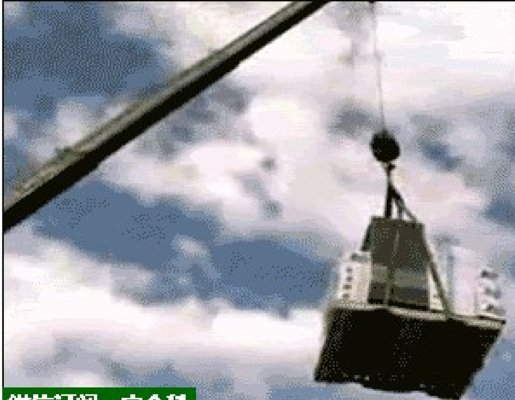

- 吊装是高危作业：吊物摆动、超载、限位失效、指挥失误
- 三个真实案例的共同点：**人不在状态**（玩手机、疲劳）+ **装置被动手脚**（力矩限位器被人为调动）
- 法规要求：起重机械安装拆卸由有资质单位承担；使用前验收；定期检验
- 特种作业人员（起重信号工、登高架设等）必须持证上岗
- 责任判定要点：是否违章指挥、是否违章作业、是否培训到位
- 吊装事故的典型链条：违章操作 → 超载/失衡 → 限位器失效 → 结构破坏 → 坠落
- 防错优先于教育：**限位器不能被旁路、超载不能被“经验”覆盖**

## 风险来源（三）：外部环境与长期代价

- 外部环境：**意外天气、自然灾害、不可抗力**
- 工程的长期社会代价，常来自“当时无法预见”的外部因素
- 案例：三门峡水利枢纽——1957 年开工，1960 年蓄水，1962 年库区淤积泥沙约 **15 亿 t**（资料口径），此后两次改建
- 教训：技术方案在经济与生态上的外部性，可能几十年后才显现
- 外部环境风险的应对：冗余设计、预警系统、应急预案、**可逆性**（留退路）
- 智能制造的外部环境：雷击、断电、网络中断、供应链中断、极端天气

## 风险的两个维度：频率与后果

- 任何风险都落在“发生频率 × 后果严重度”的平面上
- 高频低后果：夹伤、噪声、粉尘——靠管理与防护逐步降低
- 低频高后果：爆炸、坍塌、溃坝——靠本质安全与冗余，不能靠经验
- 最危险的是中间地带：频率低到没人在意，后果大到一次致命
- 经验法则（海因里希，1931）：1 起重伤背后约 29 起轻伤、300 起无伤
- 该法则只适合同质、高频场景；化工与核电样本太少，均值没有意义
- 判断：先问“属于哪一类”，再决定用统计还是用情景分析
- 一句话：频率告诉你概率，后果告诉你底线

## 可接受风险：谁定、怎么定（ALARP）

- “可接受”不是技术结论，而是风险与收益的社会谈判
- 三方共定：监管者定底线、企业定方案、受影响者定“能否忍受”
- ALARP：在不可接受与广泛可接受之间，须降至合理可行的最低水平
- 判据：继续降险的成本与所获安全严重不成比例时，才算已 ALARP
- 量级参考（英国 HSE）：工人 $10^{-3}$/年 为上限，公众 $10^{-4}$/年，$10^{-6}$/年 以下广泛可接受
- 我国 GB 36894-2018 按防护目标类别给个人风险基准，并用社会风险曲线管大事故
- 争议：成本由企业算、代价由居民担，“合理可行”由谁判断
- 一句话：ALARP 把“多大风险”换成了“还能不能再降、为什么不降”

## 风险评估的流程：四步与两条贯穿线

| 步骤 | 核心问题 | 主要工具 | 输出 |
| --- | --- | --- | --- |
| 识别 | 什么会出事 | 检查表、HAZOP、FMEA、FTA | 危险清单 |
| 分析 | 多大概率、多严重 | 定性、半定量、定量 | 风险值或等级 |
| 评价 | 能不能接受 | 矩阵、ALARP、基准值 | 可接受性结论 |
| 控制 | 怎么降、降到多少 | 层级控制、剩余风险 | 措施与复评 |

- 两条贯穿线：沟通与咨询（对内对外）、监督与评审（变更、事故、法规）
- 识别的完整性决定上限：漏掉的危险不会在后续任何一步出现
- 评价与控制的区别：评价答“是否可接受”，控制答“降到多少”
- 复评触发：措施实施后、工艺变更后、发生未遂事件后
- 分析要写清假设的适用条件，否则数字会被搬到不该用的地方
- 常见失败：只做识别不做评价；报告写完就进柜子，没人复评
- 流程的价值在每一步都有责任人签字，不在报告厚度

## 风险识别方法：四种工具的分工

| 方法 | 原理 | 适用 | 局限 |
| --- | --- | --- | --- |
| 检查表 | 按已有知识逐项核对 | 日常巡检、开工前检查 | 只查列过的项 |
| HAZOP | 引导词逐节点找偏离 | 连续流程、新工艺 | 依赖主持人与班组经验 |
| FMEA | 自下而上分析失效模式 | 部件、功能、装配 | 串联失效易漏 |
| FTA | 由顶事件向下演绎 | 已知重大后果追原因 | 顶事件之外看不见 |

- HAZOP 七个引导词：无、多、少、部分、相反、伴随、其他
- 选择：新工艺用 HAZOP，新部件用 FMEA，追原因用 FTA，日常用检查表
- 组合使用：HAZOP 找偏差、FTA 算概率、FMEA 定改进优先级
- HAZOP 的产出不是“找错”，而是每个偏差都有处置结论
- 检查表要版本化：新工艺、新设备必须更新条目
- 识别不是列清单，而是给每条危险找到它的失效路径
- 共同盲区：没被想到的失效模式，在表里风险为零

## 风险评估方法：FTA 与 ETA

[figure not shown]

- **FTA**：顶事件向下演绎，问“哪些基本事件同时成立会导致它”
- **ETA**：初始事件向上推演，问“每条分支走到什么后果”
- 读树三步：找顶事件 → 认逻辑门 → 列最小割集
- 三处“与门”：火源×油气浓度、泄漏×通风、静电积累×接触不良
- 最小割集 → 薄弱环节 → 控制措施
- 一句话：**FTA 找原因，ETA 排后果**

## 事件树：后果谱系的三个判据

[figure not shown]

- **是什么**：把每道防护的“成功／失效”按时间排成分支，末端即后果谱系
- **为什么**：FTA 倒推原因组合，ETA 正推后果轻重，一倒一正
- **怎么判断**：
  - 沿分支把概率**相乘**：$P_1\times P_2=10^{-9}$
  - 末端分级：可忽略 → 小量 → 中量 → 大量 → 极大量
  - 哪道防护没画进来——**没列出＝概率为零**
- 一句话：**ETA 的价值在暴露缺口在哪一级**

## 风险分析：定性、半定量与定量

| 层次 | 输出 | 典型方法 | 适用阶段 |
| --- | --- | --- | --- |
| 定性 | 高／中／低 | 专家判断、检查表 | 全厂初筛 |
| 半定量 | 分值或等级 | LEC、矩阵、RPN | 作业与设备排序 |
| 定量 | 年频率、F-N 曲线 | QRA、后果模拟 | 重大危险源、选址 |

- LEC 法：$D = L \times E \times C$，分别给可能性、暴露、后果打分
- 定量不是更科学，而是假设更贵：失效数据、后果模型都要钱
- 精度陷阱：输入是 $10^{-4}$ 量级的估算，输出报到小数点后三位
- 混用原则：先定性筛，再对重大风险做定量，别全厂一刀切
- 半定量的价值在“可比较”：把不同装置拉到同一把尺子上
- 定量结果必须附不确定性区间，否则等于假精确
- 一句话：方法要与决策的重要性匹配

## 风险评价：矩阵与分级

| 后果／可能性 | 极少 | 偶尔 | 可能 | 频繁 |
| --- | --- | --- | --- | --- |
| 轻微 | 低 | 低 | 低 | 中 |
| 较大 | 低 | 中 | 中 | 高 |
| 严重 | 中 | 中 | 高 | 高 |
| 特别严重 | 中 | 高 | 高 | 极高 |

- 矩阵把“概率—后果”映射为等级，用于排序与资源配置
- 四级对应四种动作：极高停止、高限期整改、中监控、低接受
- 缺陷一：格子不等距，一格之差可能是两个数量级
- 缺陷二：等级不可传递，A 优于 B、B 优于 C，推不出 A 优于 C
- 用法：矩阵只做初筛与沟通，重大风险必须回到定量与 ALARP
- 分级要落到“谁在何时做什么”，否则矩阵只是装饰
- 我国实践：风险分级管控加隐患排查治理，即双重预防机制

## 风险控制的层级：从消除到 PPE

| 层级 | 措施 | 可靠性 | 例子 |
| --- | --- | --- | --- |
| 消除 | 取消危险作业 | 最高 | 免焊连接、湿式作业 |
| 替代 | 换低危介质 | 高 | 水基清洗剂替代有机溶剂 |
| 工程控制 | 隔离、联锁、泄放 | 较高 | SIS 联锁、围堰、通风 |
| 管理控制 | 许可、培训、轮班 | 中 | 作业许可、LOTO、交接班 |
| 个体防护 | 穿戴与使用 | 最低 | 安全帽、防毒面具、耳塞 |

- 顺序不可颠倒：先设计，后管理，最后才是个人防护
- 一条措施若依赖“人不出错”，其可靠性上限就是人的可靠性
- 常见错误：用发 PPE 与签责任书替代工程改造
- 层级不是“越贵越好”：小风险用管理措施即可
- 高风险点至少两层独立措施：一层失效，另一层还在
- 每降一层，责任就从设计者转到使用者，风险随之转移
- 判断：问“这个措施失效时，下一个拦住它的是什么”

## 剩余风险与风险转移

- 剩余风险：措施全部落实后仍然存在的风险，必须识别、记录、告知
- 三层剩余：设计剩余、施工实施剩余、使用与误用剩余
- 转移不等于消除：保险赔钱，不赔命；赔偿总在伤害之后
- 三种转移：保险（财务）、合同（约定责任）、外包（转给第三方）
- 保险问题一：道德风险——有赔付兜底，防范动机下降
- 保险问题二：逆向选择——高风险者更愿投保，保费被迫上浮
- 保险问题三：责任不可转移——民事可转，刑事与职业责任不可转
- 告知义务：剩余风险要写进说明书与培训，否则转移变成隐瞒
- 一句话：能被转移的是损失，不能被转移的是责任

## 正常事故：紧耦合与复杂交互

- Charles Perrow：高风险技术有两个特征，使事故难以预测、难以控制
  - **紧耦合**：一环失效在很短时间内传到下一环，**没有纠错时间**
  - **复杂交互**：部件之间以**未被预料的方式**相互影响
- 这类系统包括化工装置、核电、电网、航天、核武器系统
- 1962 年纽约扬克斯锅炉爆炸：安全阀锈死、燃料切断被电工拆开、值班员关死总阀、赶上发薪日午餐时间 → 锅炉如火箭穿透三层楼，**25 死、近 100 人重伤**
- 判断：故障树与事件树**都不可能预测**这条事件链
- 但有一条简单改造能切断链条：燃料切断系统被断开时，禁止点火
- 一句话：**有些事故是系统属性；降低风险靠解耦与独立保护，不靠追责个人**

## 四维度闭环：评估、管理、认知、沟通

- **风险评估** → **风险管理** → **风险认知** → **风险沟通**：不是线性流程，而是闭环
- 风险认知：公众接受度受**自由意志、福利补偿、对风险的控制感、恐惧程度、未知程度**影响
- 风险沟通：在利益相关方之间有目的地交换风险信息（ASCE 知识体系强调的重点）
- 凯悦的教训：结构工程师未向分包商传达关键节点的责任与风险；分包商与工程师对变更的影响都未有效沟通
- 工程实践的落点：把“我认为安全”变成“**对方理解并同意承担**”
- 智能制造场景：报警信息给谁看、以什么形式给、对方能不能看懂

## 风险认知：四种系统性偏差

| 偏差 | 机制 | 工程场景 | 对策 |
| --- | --- | --- | --- |
| 可得性 | 见过的被高估 | “我们厂从没出过事” | 引入行业事故库 |
| 概率忽视 | 后果越可怕越忽略概率 | 恐惧压过数字 | 换成频率表述 |
| 乐观偏差 | 觉得自己高于平均 | 不系安全带、不戴护具 | 强制与抽查 |
| 锚定 | 首个估计定锚 | 初版风险值沿用到投产 | 独立复算 |

- 熟悉性悖论：熟悉的风险被低估（开车），陌生的被高估（辐照食品）
- 组织版偏差：正常化偏差——警报响多了就调阈值，最后没人信
- 对策：把概率换成频率、给对比锚、让数据可见
- 偏差的对立面不是理性，而是程序：复核、对比、盲算
- 群体放大：一个班组共享同一套偏差，会把异常当正常
- 讲给一线听：把“每万人每年一次”换成“这个班组十年一次”
- 一句话：偏差无法消除，只能设计流程去对冲

## 专家与公众：差异的三个层次

| 层次 | 专家的算法 | 公众的算法 | 沟通含义 |
| --- | --- | --- | --- |
| 事实层 | 概率与后果的估计 | 感知死亡数偏低约 100 倍 | 先补事实，别急着说服 |
| 概念层 | 风险与可接受分开 | “risky”是警示信号 | 两个词分开用 |
| 道德层 | 成本收益 | 知情同意与公平分配 | 谈程序，不只谈数字 |

- 事实层的差距真实存在：专家感知死亡数约低 10 倍，公众约低 100 倍
- 概念层：公众把“新、陌生、来源不可信”直接读成“风险大”
- 道德层：公众问“谁让我承担、我能不能拒绝”，专家只答“概率乘后果”
- 所以“公众不懂科学”是误诊：分歧多在后两层，不在算术
- 事实层靠数据公开补救，道德层靠程序补救，不能互相替代
- 专家自己也会低估，所以“听专家的”不是无条件原则
- 一句话：先承认三个层次，再谈沟通

## 风险沟通：五条原则与三个做法

- 原则一：不要把“风险”当“危害概率”用，两个词分开说
- 原则二：慎说“没有零风险”——公众的“零风险”常指“熟悉、无需再议”
- 原则三：承认专家也会错、也有局限——信任来自坦白，不来自保证
- 原则四：记住监管者有保护公众的特殊义务，可能高于成本收益
- 原则五：专业学会有责任提供尽可能客观的概率信息
- 做法一：早说，不等定稿；做法二：说清“不知道什么”
- 做法三：给出可行动的选项（做什么、往哪走、找谁问）
- 判断：沟通目标不是让公众接受，而是让公众有能力判断
- 一句话：信任是沟通的通货，数字只是语言

## 风险分配：谁承担、谁受益

- 四种错位：受益者不是承担者、承担者不是决策者、承担者不知情、当代与后代错位
- 教材例：墨西哥湾 LNG 接收站——全国用气受益，邻近居民独担爆炸风险
- 三种形态：地理（邻避）、职业（工人）、时间（后代）
- 补偿的边界：能补收入损失，补不了健康与生命
- 补偿的陷阱：钱一到手，“同意”就被推定为成立
- 罗尔斯判据：不平等只有在最不利者也受益时才可接受
- 工程落点：选址阶段就问“风险落在谁头上”，不要等到环评
- 一句话：风险可以分配，但不能偷偷分配

## 环境正义：休斯敦的填埋场与焚化炉

- 1980 年代研究：休斯敦把全部垃圾填埋场与 75% 的焚化炉放在非裔社区
- 当时非裔居民只占全市人口约 25%
- 加州研究类似：环境负担最重的邮编区，集中在拉丁裔与非裔聚居区
- 这不是巧合：选址遵循“政治阻力最小”原则
- 后果叠加：污染、房价下跌、健康损失，且缺少申诉资源
- 教材把博帕尔、切尔诺贝利也列为环境正义问题——最穷的人住得最近
- 工程含义：选址与排放许可也是伦理决策，不只是技术经济比较
- 一句话：环境负担总是顺着权力的坡度往下流

## 预防原则：科学不确定时怎么办

- 里约宣言原则 15（1992）：严重或不可逆损害威胁时，不得以缺乏充分科学确定性为由推迟预防措施
- Wingspread 声明（1998）：即使因果关系未完全确立，也应采取预防措施
- 欧盟 2000 年通报：适用于证据不足或不确切的情形，须比例、非歧视、一致，并随新证据复审
- 中国《环境保护法》第五条：保护优先、预防为主、综合治理、公众参与、损害担责
- 三个应用场景：转基因食品、纳米材料、大模型与算法
- 三条批评：可能阻碍创新；“不确定”无法量化；举证责任倒置
- 与成本收益的张力：一个问“最坏能坏到什么程度”，一个问“期望值划算吗”
- 一句话：不确定不是不作为的理由，也不是乱作为的借口

## 成本收益分析在风险决策中的局限

- 合理位置：无严重权利侵害时，它给出可比较、可复核的排序
- 局限一：影响列不全——未预见的后果在表里等于零
- 局限二：货币化困难——湿地、物种、健康寿命怎么折成钱
- 局限三：只看总和、不看分配——多数人获益可掩盖少数人受害
- 局限四：没有知情同意的位置——被安排的人从未被问过
- 技术难点：生命价值靠补偿性工资推算，穷人与富人的命价不同
- 技术难点：贴现率——把三十年后的健康折现，等于系统性低估后代
- 改进：成本效果分析、多准则决策、设不可逾越的安全底线
- 一句话：能算的算清楚，不能算的要说出来

## 知情同意：三个条件在工程中的变形

| 维度 | 医疗知情同意 | 工程风险知情同意 |
| --- | --- | --- |
| 告知内容 | 病情、方案、风险 | 危害、概率、可替代方案 |
| 能力判断 | 患者行为能力 | 公众的概率理解能力 |
| 自愿性 | 无胁迫、可拒绝 | 工人可能没有别的就业选择 |
| 退出权 | 可拒绝治疗 | 居民无法搬走、无法退出 |

- 三条件：不胁迫、有信息、有能力，缺一条即不成立
- 变形一：工人的“自愿”常是就业压力下的无奈
- 变形二：居民面对集体施加的风险，无法逐一同意
- 变形三：信息给了，但“给了”不等于“懂了”
- 替代机制：补偿、代表、听证与申诉程序
- 判断标准：说得出“我拒绝的后果是什么”，才算真的懂
- 一句话：能拒绝，才算同意

## 工程风险的伦理评估：原则、途径与程序

- **四条原则**：以人为本、预防为主、整体主义、制度约束
- **三条途径**：
  - 专家评估：技术上的概率与后果
  - 大众评估：受影响者的感受与价值判断
  - 社会评估：成本收益分析与公共政策判断
- **三道程序**：
  - **信息公开**：先让利益相关方知道
  - **确立利益相关方与利益关系**：谁受益、谁承担、谁有发言权
  - **民主原则**：组织充分交流、商谈与对话
- 评估的效力来自**程序的可接受性**，不只来自数字的精确性
- 一句话：**技术评估回答“多大风险”，伦理评估回答“谁说了算”**

## 案例：某化工装置风险评估报告（教学示例）

[figure not shown]

- 对象：环氧乙烷储罐区，2 台 100 m³ 球罐，年运行 8000 h
- **识别**：HAZOP 分 5 个节点、七个引导词，得 37 条偏差
- **分析**：泄漏、闪蒸、蒸气云爆炸，泄漏频率取数据库 $10^{-4}$/年
- **评价**：个人风险 $2\times10^{-5}$/年，高于企业自定 $10^{-5}$/年 目标
- **控制**：加 SIS 联锁（SIL 2）、紧急切断、围堰与远程隔离
- **复评**：泄漏频率降至 $3\times10^{-6}$/年，个人风险进入 ALARP 区

## 案例：自动驾驶的风险取舍

- 分级（GB/T 40429-2021）：L0–L2 人监控，L3 限定条件下系统执行、人须接管，L4–L5 系统负责
- 取舍一：安全阈值——要比人类驾驶员安全几倍才允许上路
- 取舍二：验证里程——要证明事故率更低，需数十亿英里，只能靠仿真与场景库
- 取舍三：接管悖论——L3 要求人数秒内接管，而人最不擅长监控自动化
- 真实事件：2018-03-18 亚利桑那坦佩，Uber 测试车撞击行人致死
- 该系统提前约 5.6 s 探测到行人，但设计上不执行紧急制动
- 责任：L0–L2 驾驶员担责，L3 起车企进入责任链，L4–L5 运营方担责
- 伦理争议：“撞谁”是伪问题，真问题是风险预算给谁、由谁定
- 一句话：风险取舍从个人瞬间判断，变成写进代码的公共政策

## 风险清单与应急预案

| 编号 | 风险描述 | 等级 | 控制措施 | 责任人 |
| --- | --- | --- | --- | --- |
| R-01 | 储罐超压 | 高 | SIS 联锁、安全阀年检 | 设备主管 |
| R-02 | 装卸软管脱落 | 中 | 拉断阀、双人确认 | 储运班长 |
| R-03 | 停电致冷却中断 | 高 | 双电源、柴油泵 | 电气主管 |
| R-04 | 雷击引发火灾 | 中 | 接地检测、防雷年检 | 安全经理 |

- 清单是活文档：编号、描述、等级、措施、责任人、期限、复查
- 更新触发：变更、事故、演练、法规、季节性风险
- 预案三级：综合预案、专项预案、现场处置方案（岗位卡）
- 演练频次：综合或专项每年至少一次，现场处置每半年至少一次
- 常见病：抄模板、电话打不通、集合点被占、只演不评
- 挂钩：每条高风险都要有对应的处置方案
- 一句话：预案由“最坏那天”检验，不由文件厚度检验

## 风险沟通的三次失败

| 事件 | 信息发生了什么 | 后果 |
| --- | --- | --- |
| 切尔诺贝利 1986-04-26 | 最初几乎不发布，瑞典检测到跨境辐射才承认 | 邻近城市延迟疏散 |
| 松花江 2005-11-13 | 吉化爆炸后先称供水未受影响，后承认污染 | 哈尔滨停水四天 |
| 福岛 2011-03-11 | 扩散预测已算出却未及时公开 | 部分居民向高剂量方向撤离 |

- 共同点：先控制信息、再控制损失——顺序反了
- 代价：信任一旦崩塌，后续正确信息也被当作隐瞒
- 教训：坏消息要一次说清、说全、说早
- 教训：不确定就说不确定，别用确定口吻换安稳
- 失败模式一：以“避免恐慌”为由拖延，结果恐慌更大
- 失败模式二：多部门口径不一，公众只记住最坏的那条
- 一句话：延迟发布不会让风险变小，只会让信任变小

## 风险管理的组织与制度

| 防线 | 主体 | 主要工具 |
| --- | --- | --- |
| 一线 | 班组与岗位 | 交接班、巡检、作业许可 |
| 专业 | 安全、工艺、设备 | 风险分级、MOC、PSM |
| 监督 | 审计、监管、第三方 | 检查、审核、事故调查 |

- 责任体系：主要负责人全面负责，“三管三必须”，责任到岗到人
- 双重预防：风险分级管控（事前）加隐患排查治理（事中）
- 变更管理（MOC）：工艺、设备、人员、法规任一变更都要重评风险
- 过程安全（PSM）：工艺危害分析、操作规程、机械完整性、承包商、应急
- 失效征兆：事故报告变少、整改超期、演练走过场、安全与产量冲突
- 安全投入的悖论：不出事时像浪费，出事时嫌不够
- 一句话：组织决定风险，制度决定组织

## 智能制造与动态风险

| 风险源 | 机理 | 参照 | 对策 |
| --- | --- | --- | --- |
| 算法 | 模型漂移、分布外输入 | 误判与漏判 | 版本管理、人工兜底 |
| 网络 | IT 与 OT 融合后暴露面扩大 | 2010 震网、2017 勒索病毒 | 分区隔离、白名单 |
| 人机协作 | 共享工作空间 | ISO 10218、ISO/TS 15066 | 功率与力限制、速度监控 |

- 动态性：OTA 升级、换型、模型更新都会改变风险剖面
- 一次评估不够：风险档案要跟版本走，随变更重做
- 治理三原则：可追溯（日志与版本）、可停机（失效安全）、可复核（人工兜底）
- 自动化偏见：系统越可靠，人越不看它，出事时越接不住
- 供应链风险：一家芯片或软件供应商断供，整线停摆
- 数据风险：训练数据偏差到现场会表现为“误报”
- 一句话：智能系统不是更安全，而是风险换了形态

## 第一部分小结：风险伦理五问

- 五问：会出什么事、多大概率、能否接受、谁承担、谁同意
- 方法链：识别、分析、评价、控制、复评
- 三个不能省：剩余风险要告知、分配要公开、同意要真实
- 三个常见谬误：零风险、以平均值代替尾部、以合规代替可接受
- 认知提醒：专家也会低估计 10 倍，公众的“risky”不是算术错误
- 制度落点：清单、预案、变更管理、双重预防
- 智能制造的增量：动态、软件化、责任分散
- 一句话：核心不是算得更准，而是让承担风险的人有发言权

## 推导留给 AI：工程风险与评估（汇总）

- 用“评估—管理—认知—沟通”四维度分析 2016 年奉贤锅炉爆炸，指出哪一维最先失效。
- 三门峡的泥沙问题，用今天的风险评估方法（FTA／ETA／ALARP）能否提前发现？需要哪些数据？
- 人为因素难预测，为什么工程上更依赖“防错”而不是“教育”？请用两个装置例子说明。
- 为一条智能制造产线列出 5 个技术风险、3 个人为风险、2 个外部风险，并给出对应防护。

# 第二部分 · 安全事故 vs 安全责任事故

- 两个概念与判定四问：安全制度有没有被违反、管理与操作有没有尽职（可预见？义务尽了？违章？管理到位？）
- 领导责任的五种可核查情形
- 案例：甬温线 7·23、凤凰沱江大桥、锅炉爆炸
- 法规：建设工程安全生产管理条例的五方主体责任

## 事故：从结果事件到可调查对象

- 事故是造成人员伤亡、职业病、财产损失或环境破坏的意外事件
- 三个要素：能量或危险物质失控、人员或资产处于影响范围、后果可核实
- 分类维度：行业领域、事故类别（20 类）、后果等级（四级）
- 生产安全事故：生产经营活动中发生的、造成人身伤亡或直接经济损失的事件
- 定级只看三项：死亡人数、重伤人数、直接经济损失

| 等级 | 死亡人数 | 重伤人数 | 直接经济损失 |
| --- | --- | --- | --- |
| 特别重大 | 30 人以上 | 100 人以上 | 1 亿元以上 |
| 重大 | 10～30 人 | 50～100 人 | 5000 万～1 亿元 |
| 较大 | 3～10 人 | 10～50 人 | 1000 万～5000 万元 |
| 一般 | 3 人以下 | 10 人以下 | 1000 万元以下 |

- 三项满足其一即按最高等级认定；“以上”含本数，“以下”不含本数
- 依据：国务院令第 493 号《生产安全事故报告和调查处理条例》

## 一字之差：事故与责任事故

- 同一起事故，先作事实判断，再作规范判断
- 事故回答“发生了什么、后果多大”；责任事故回答“应尽义务是否缺失”

| 维度 | 事故（事实判断） | 安全责任事故（规范判断） |
| --- | --- | --- |
| 判断对象 | 事件、后果、因果链 | 义务、过错、因果关系 |
| 依据 | 现场、鉴定、损失核定 | 法规、规程、职责、证据 |
| 证明 | 损害如何发生 | 谁应防住而未防住 |
| 后果 | 工伤、赔偿、整改 | 行政、民事、刑事责任 |
| 可变性 | 后果固定 | 定性随证据变化 |

- 两者不是互斥关系：一起事故可以同时是责任事故
- 非责任事故：不可抗力、技术局限、第三人故意、受害人故意
- “死了人”不等于责任事故，“没死人”也可能被追责

## 判定的四个关键问题

- **问 1：可预见吗？** 同类失效是否已知、是否被记录、是否有标准要求
- **问 2：应尽的注意义务尽了吗？** 设计复核、检验检测、作业监护、培训交底
- **问 3：违章了吗？** 是否违反强制标准、操作规程，是否存在违章指挥与违章作业
- **问 4：管理到位吗？** 责任制、专项施工方案、验收、应急预案、隐患排查
- 判定规则：四问全“否”→ 倾向安全事故（非责任）；任一“是”→ 倾向责任事故
- 判定主体与程序：政府事故调查组（特别重大事故由国务院或授权部门组织）
- 证据决定结论：设计文件、变更记录、施工日志、监理记录、检验报告、培训档案

## 责任事故的四项注意义务

- 责任事故的核心不是“后果重”，而是“义务缺”
- 四项义务按时间顺序递进：预见、避免、告知、纠正

| 义务 | 判断问题 | 证据 | 常见抗辩 |
| --- | --- | --- | --- |
| 预见 | 当时应否知道风险 | 同类事故、标准、试验、告警 | 知识当时不存在 |
| 避免 | 有无能力与条件防止 | 冗余、联锁、检验、监护 | 成本或技术不可行 |
| 告知 | 是否向有权者揭示风险 | 报告、邮件、纪要、交底 | 已口头告知 |
| 纠正 | 发现后是否处置 | 隐患单、停机记录、验收 | 无权停机 |

- 过错通常只落在其中一环，不必四项全缺
- 举证不是“我说我尽了”，而是“我能拿出履行的痕迹”
- 一句话：义务不是道德期待，是可核查的动作

## 领导责任的五种情形

有下列情况之一时，有关领导应负领导责任：

1. **制度缺失**：安全生产责任制、规章、操作规程不健全，职工无章可循，造成伤亡事故
2. **培训缺失**：未按规定进行安全教育与技术培训，或职工未经考试合格上岗操作
3. **设备失管**：机械设备超过检修期限或超负荷运行，或设备有缺陷又不采取措施
4. **环境失管**：作业环境不安全，又未采取措施
5. **三同时缺失**：新建、改建、扩建项目的尘毒治理与安全设施，未与主体工程同时设计、同时施工、同时投入使用
- 结论：领导责任不是“出了事就要负责”，而是**五种可核查的管理缺失**

## 事故原因：直接、间接与根本

- 原因分析不是列清单，而是分层追问“为什么允许它存在”
- 直接原因回答“什么触发了失效”，间接原因回答“为什么没被挡住”

| 层次 | 回答的问题 | 典型内容 |
| --- | --- | --- |
| 直接原因 | 什么触发了失效 | 人的不安全行为、物的不安全状态、环境触发 |
| 间接原因 | 为什么它得以存在 | 管理缺陷、培训不足、检验缺失、违章指挥 |
| 根本原因 | 为什么管理会失效 | 目标排序、考核激励、治理结构、安全文化 |

- 停在直接原因，整改只能“注意一点”；停在间接原因，整改只能“再发一个文件”
- 5 Whys 问到“工人粗心”就停，是伪根因
- 判据：整改措施能否防止同类事故再发，而不是能否写进报告

## 事故调查：程序与证据链

- 调查不是“找一个人负责”，而是还原时间线、因果线与责任线

| 阶段 | 关键动作 | 时限 | 产出 |
| --- | --- | --- | --- |
| 报告与救援 | 先救人、保护现场 | 负责人 1 小时内上报 | 事故快报 |
| 调查组成立 | 政府牵头，安监、监察、公安、工会，邀请检察 | 按事故等级 | 调查组 |
| 取证与鉴定 | 勘验、询问、书证、技术鉴定 | 60 日，可延 60 日 | 证据卷宗 |
| 报告与批复 | 原因、性质、责任、整改 | 收到报告后 15 日批复，特别重大 30 日 | 调查报告 |

- 八类证据：书证、物证、视听资料、电子数据、证言、陈述、鉴定意见、勘验笔录
- 责任线四问：谁决定、谁执行、谁验收、谁监管
- 常见败笔：现场被清理、记录缺失、鉴定与勘验矛盾

## 事故报告与“四不放过”

- 报告时限：现场立即报负责人；负责人 1 小时内报监管部门
- 逐级上报每级不超过 2 小时；紧急情况可以越级报告
- 报告内容：单位概况、时间地点、经过、伤亡与损失、措施与可能后果
- 四不放过：原因未查清、责任未处理、整改未落实、人员未受教育
- 它的价值：把“结案”变成“闭环”，防止同类事故再发
- 它的盲区：重追责、轻系统；重个人、轻制度
- 补一条“第五不放过”：同类风险是否已识别并消除
- 判据：整改措施能被验证，而不是写在报告里

## 事故统计：指标、口径与陷阱

- 两类分母：千人率用**平均职工人数**，工时率用**实际总工时**

$$R_d=\frac{N_d}{N}\times 10^{3},\qquad R_i=\frac{N_i}{N}\times 10^{3},\qquad F=\frac{N_s}{H}\times 10^{6},\qquad S=\frac{D}{H}\times 10^{6}$$

- $N_d$ 死亡、$N_i$ 重伤、$N$ 平均职工人数；$N_s$ 伤害人数（含死亡）、$H$ 实际总工时、$D$ 总损失工作日
- 损失工日口径（GB 6441）：轻伤低于 105 日，重伤等于或超过 105 日，死亡按 6000 日折算

| 指标 | 分子与分母 | 用来看什么 |
| --- | --- | --- |
| 千人死亡率 | 死亡人数÷平均职工人数 | 跨企业规模比较 |
| 千人重伤率 | 重伤人数÷平均职工人数 | 跨企业规模比较 |
| 百万工时频率 | 伤害人数（含死亡）÷实际总工时 | 暴露风险比较 |
| 伤害严重率 | 总损失工作日÷实际总工时 | 伤害严重程度 |

- 陷阱：分母混用、少报轻伤与未遂、只盯死亡；指标变好可能只是报告变少

## 案例：甬温线 7·23

- **时间**：2011 年 7 月 23 日 20 时 30 分 05 秒
- **地点**：甬温线浙江省温州市境内
- **事件**：北京南开往福州的 D301 次列车，追尾杭州开往福州南的 D3115 次列车
- **后果**：**40 人死亡、172 人受伤**；中断行车 **32 小时 35 分**；直接经济损失 **19371.65 万元**
- **技术链**：雷击 → LKD2-T1 型列控中心设备故障 → 轨道电路发码异常 → D3115 停于区间，D301 未及时收到停车信号
- **责任链**：列控中心设备存在严重设计缺陷、上道使用审查把关不严、雷击故障后应急处置不力
- 定性：这是一起**责任事故**——技术因素触发，管理因素定性

## 案例：凤凰沱江大桥

- **时间**：2007 年 8 月 13 日 16 时 40 分许
- **地点**：湖南省湘西土家族苗族自治州凤凰县，正在建设中的堤溪沱江大桥
- **事件**：在拆除脚手架过程中，大桥发生坍塌
- **后果**：**64 人死亡、22 人受伤**，直接经济损失巨大
- **调查认定的问题**：砌筑质量差、砂浆强度不足、拆架程序不当、监理与施工管理失职
- 定性：**责任事故**
- 与凯悦的共性：**施工阶段的临时工况**（拆架、临时支撑）往往比永久结构更危险

## 案例：事故现场与“能证明的才叫责任”

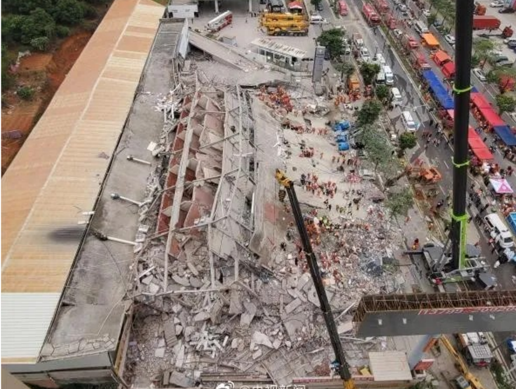

- 事故调查第一步是**固定证据**：现场、图纸、记录、人员证词
- 证据链：照片录像、监控、材料取样、计算复核、操作记录
- 责任判定依赖：设计文件与变更记录、施工日志、监理记录、检验报告、培训档案
- 智能制造的价值：MES／追溯系统可以在事故**之前**就把这些证据自动留痕
- 结论：**能证明的才叫责任**

## 案例：挑战者号（1986-01-28）

- 1986 年 1 月 28 日 11:38，肯尼迪航天中心，STS-51-L
- 升空 73 秒解体，**7 名宇航员**遇难
- 直接原因：右侧固体助推器场接头 O 型圈低温失去弹性，热气泄漏
- 发射前夜预测气温 26°F，O 型圈约 29°F；此前密封圈最低 53°F
- 电话会：Thiokol 工程师建议低温不发射，NASA 质疑数据不足
- NASA 需要成功飞行，Thiokol 需要新合同；数据不完整成为反转理由
- 异常并非首次：1981、1984、1985 年多次 O 型圈侵蚀均被接受
- Rogers 委员会认定决策过程有缺陷；Feynman 用冰水演示回弹丧失
- 教训：异议没有制度出口，可接受风险的边界被逐次放宽

## 案例：哥伦比亚号（2003-02-01）

- 2003 年 1 月 16 日发射，STS-107，执行为期 16 天的科学任务
- 起飞 81.7 秒，外部贮箱泡沫块击中左翼前缘
- 泡沫块约手提箱大小，在 RCC 面板 8 号附近砸出约 10 英寸孔
- 再入时超过 5000°F 的高温气体进入翼内，结构失效后解体
- **7 名宇航员**遇难
- 工程师 Rocha 等要求获取更清晰图像、请求军方成像，被管理层拒绝
- 机组直到再入前才被告知，且被说明“不构成安全问题”
- CAIB 认定物理原因与组织原因并重：文化壁垒、异议被过滤、正常化偏差
- 教训：同一个组织，17 年后再犯同一种错

## 案例：切尔诺贝利（1986-04-26）

- 1986 年 4 月 26 日 01:23:40，四号机组，RBMK-1000 石墨慢化沸水堆
- 停机前做“汽轮机惰转供电”试验，试验与核安全未做协调
- 功率意外跌至约 30 MWt，为拉回功率抽出过多控制棒
- 运行反应性裕度降至 8 根，低于规程 15 根；部分自动保护被停用
- 01:23:40 按 AZ-5，控制棒石墨端头引发“正停堆”效应
- 功率骤升，燃料碎裂，蒸汽爆炸掀开约 1000 t 的反应堆上盖
- 石墨与燃料起火，大量放射性物质释放，污染欧洲多国
- **30 人** 3 个月内死亡：2 人死于爆炸，28 人死于急性放射病
- 30 km 内约 11.6 万人疏散，后续再迁移约 22 万人
- 教训：设计缺陷、安全文化缺失、信息封闭三者叠加

## 案例：福岛核事故（2011-03-11）

- 2011 年 3 月 11 日 14:46，M9.0 地震，1～3 号机组运行
- 地震后自动停堆，外部电源丧失，应急柴油机启动
- 15:42，约 15 m 海啸淹没厂区，13 台应急柴油机有 12 台失效
- 全厂断电，冷却丧失，1～3 号机组堆芯 3 天内相继熔毁
- 1、3、4 号机组厂房相继氢气爆炸，大量放射性释放
- 设计基准：最初 3.1 m，2002 年 5.7 m，2009 年 6.1 m
- 2008 年 TEPCO 曾估算 15.7 m，却未迁移发电机、未密封厂房
- 约 16 万人疏散；无急性放射病死亡，有 2313 例灾害相关死亡
- 国会调查委员会：这是“可以预见、可以预防”的人为灾难
- 教训：设计基准不是历史最大值，而是必须持续重估的风险

## 案例：扬克斯锅炉爆炸（1962）

- 1962 年 10 月 2 日，扬克斯电话公司账务大楼；管理员首次启动 1 号锅炉
- 地下室三台低压燃油锅炉（低于 6 psi），不受 ASME 规范覆盖

| 防护 | 本应做什么 | 实际状态 |
| --- | --- | --- |
| 燃料切断 | 超压自动断油 | 电工断开，未告知管理员 |
| 总汽阀 | 蒸汽通往散热器 | 当天回暖，关闭总汽阀，锅炉憋压 |
| 安全阀 | 超压自动泄放 | 上次试车后锈死，未手动试验 |
| 压力表 | 提示管理员停炉 | 管理员离岗，无人观察 |
| 人在场 | 最后一道判断 | 午休去银行兑现工资 |

- 1 号锅炉爆炸，炉体穿过食堂，**25 人死亡、近 100 人重伤**
- 五道防护同时失效；FTA／ETA 难以预测这条链
- 教训：低压不等于低风险，隔离必须告知、挂牌、上锁

## 案例：起重机倾覆（超载与违规）

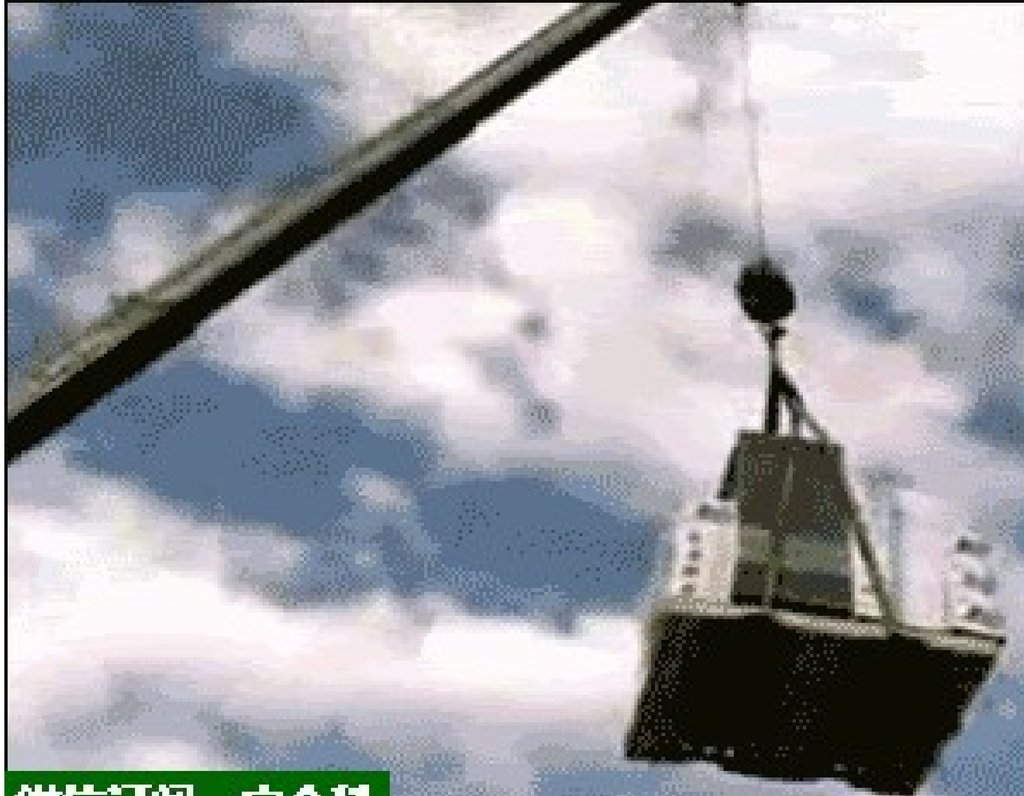

- 25 t 汽车吊，32 m 主臂，6 m 幅度，额定起重量 7.5 t
- 实际吊物 9.8 t，超载约 31%；力矩限制器被短接
- 支腿在回填土上、垫板不足，雨后下沉→幅度增大→倾覆力矩超限
- 违规链：超载→限位失效→地基失效→幅度增大→倾覆
- 责任链：违章指挥、无证操作、设备失管、方案缺失
- 一句话：倾覆不是“突然”，是四个约束同时被拿掉

## 事故链的共同模式

- 这些事故看下来，原因不是“某个人坏”，而是四条机制反复出现

| 模式 | 表现 | 案例证据 | 制度对策 |
| --- | --- | --- | --- |
| 组织压力 | 进度、成本、政治压过安全 | 挑战者发射窗口、福岛重估搁置 | 安全否决权 |
| 正常化偏差 | 异常被接受，边界逐次放宽 | O 型圈侵蚀、泡沫撞击 | 偏差必须关闭 |
| 信息屏蔽 | 坏消息上不去，异议被过滤 | 哥伦比亚“文化篱笆” | 独立通道 |
| 紧耦合 | 失效传播快，没有隔离时间 | 扬克斯锅炉链、切尔诺贝利 | 冗余与隔离 |

- 四者不是并列，而是串联：压力→偏差→屏蔽→失效
- 共同前提：没有人故意制造事故，每个人都只对自己的局部负责
- 共同后果：防护层层失效，最后一层常是“人刚好不在”
- 判据：组织是否允许坏消息低成本地上浮

## 从事故教训到制度设计

- 教训只有变成制度，才不会随责任人离开而消失

| 教训 | 制度工具 | 可检验标志 |
| --- | --- | --- |
| 调查不独立 | 独立调查组、技术鉴定分离 | 报告能否公开 |
| 异议无出口 | 独立安全官、匿名报告、异议记录 | 异议是否被回复 |
| 指标失真 | 未遂与前兆指标、数据审计 | 上报率与整改率 |
| 设计基准过时 | 定期重估、外部审查 | 重估记录与行动 |
| 整改不闭环 | 整改验收、复产条件 | 同类事故复发率 |

- 制度设计三原则：独立、可核查、可追责
- 把“四不放过”升级为“四有”：有证据、有整改、有验收、有公开
- 智能制造的接口：MES／EHS 留痕，但数据用途要先约定

## 建设工程安全生产管理条例：五方主体责任与设备检验要求

| 主体 | 核心安全责任 | 关键条款 |
| --- | --- | --- |
| 建设单位 | 提供真实资料；不得提出不符合强制标准的要求；落实安全作业环境与安全施工措施费用 | 第 6–9 条 |
| 勘察单位 | 按法律法规与强制标准勘察，文件真实、准确、完整 | 第 12 条 |
| 设计单位 | 按强制标准设计，防止因设计不合理导致生产安全事故 | 第 13 条 |
| 监理单位 | 审查施工组织设计与专项施工方案是否符合强制标准 | 第 14 条 |
| 施工单位 | 主要负责人全面负责；总包对现场负总责；专项方案；三类人员考核；教育培训 | 第 21、24、26、36、37 条 |
| 设备与检验 | 提供合格设备；定期检验；出具安全合格证明文件 | 第 15–19 条 |

- 适用范围：土木工程、建筑工程、线路管道和设备安装工程、装修工程（第 2 条）
- 方针：**安全第一、预防为主**（第 3 条）

## 条例关键条款（一）：建设、设计、监理

- **第七条**：建设单位不得对勘察、设计、施工、监理提出不符合法律、法规与强制性标准规定的要求
- **第八条**：建设单位在编制工程概算时，应确定**安全作业环境及安全施工措施所需费用**
- **第九条**：建设单位不得明示或暗示施工单位购买、租赁、使用不符合安全施工要求的防护用具、机械设备
- **第十三条**：设计单位应按法律法规与强制标准设计，**防止因设计不合理导致生产安全事故**
- **第十四条**：监理单位应审查施工组织设计中的安全技术措施或专项施工方案是否符合强制性标准
- 对照凯悦：业主三次否决“现场设计代表”的经费，正是第七条、第八条要禁止的行为

## 条例关键条款（二）：施工单位

- **第二十一条**：施工单位主要负责人依法对本单位安全生产工作**全面负责**；建立安全生产责任制度
- **第二十四条**：实行施工总承包的，由**总承包单位对施工现场的安全生产负总责**
- **第二十六条**：对**危险性较大的分部分项工程**编制专项施工方案（基坑、模板、起重吊装、脚手架、拆除爆破等）
- **第三十六条**：主要负责人、项目负责人、专职安全生产管理人员须经考核合格
- **第三十七条**：作业人员进入新岗位或新施工现场前接受安全教育培训；未经培训或考核不合格不得上岗
- 第六章：生产安全事故的应急救援与调查处理；第七章：法律责任（罚款、停业、降资质、吊证书、刑事责任）

## 从条例看责任链条 + 智能制造场景

- 一条完整链条：建设单位（给条件）→ 勘察设计（出方案）→ 施工单位（干活）→ 监理（盯着）→ 设备供应与检验（给工具）→ 政府监管
- 事故 → 查链条上哪一环的“应尽义务”缺失 → 定责任
- 智能制造的四条对应：
  - **MES** 记录操作与工艺参数（谁在什么时候做了什么）
  - **PLM** 记录设计变更与批注（变更有没有回到计算）
  - **EHS 系统** 记录培训、检查、隐患整改（培训与检查是否到位）
  - **追溯系统** 还原事故前状态（设备、物料、人员、参数）
- 关键问题：数据是“为追责”还是“为改进”？——先讲清规则，再采集数据

## 本部分小结：事故是系统的镜子

- 事故分级看后果，责任定性看义务；两者不能互相替代
- 责任事故的四项义务：预见、避免、告知、纠正
- 原因分三层：直接、间接、根本；停在“人粗心”就是没查完
- 调查靠证据链，处理靠闭环；四不放过要补上系统改进
- 六个案例的共同模式：压力、偏差、屏蔽、紧耦合
- 制度转化：独立调查、异议通道、前兆指标、设计基准重估

> 事故调查的目的，不是找到一个可责备的人，而是找到一组可修改的条件。
- 下一部分：工程师与组织——为什么好人也会沉默

## 推导留给 AI：安全事故与责任判定（汇总）

- 用判定四问分析奉贤锅炉爆炸，写出每一问的证据清单（缺哪份证据会导致无法定性）。
- 甬温线事故中，哪些环节属于“技术因素”、哪些属于“管理因素”？请画一条责任链。
- 建设工程五方主体中，哪一方的责任最难被证据固定？为什么？
- 如果一家企业用 MES 数据追责员工，追溯系统会怎样被“反向使用”？请设计一条防止这种用法的规则。

# 第三部分 · 工程师与组织

## 组织中的工程师：多重角色与多重忠诚

- 同一个人，四重角色：雇员、专业人士、组织成员、公民
- 每重角色对应一套义务，义务之间并不天然一致
- 雇主要求忠诚与效率；职业要求公众安全优先；公民要求守法与发声
- 冲突不是道德缺陷，而是角色设计的结构性后果
- 三种典型冲突：知情不报、被要求签字、被要求“按进度办”

| 角色 | 义务对象 | 判断标准 | 冲突表现 |
| --- | --- | --- | --- |
| 雇员 | 雇主 | 合同与绩效 | 服从与异议 |
| 专业人士 | 公众 | 准则与技术标准 | 签字与拒签 |
| 组织成员 | 团队 | 共识与忠诚 | 沉默与举报 |
| 公民 | 法律与共同体 | 法律与良知 | 旁观与作证 |

- 一句话：角色越多，越需要一条**公开的排序规则**

## 职业矛盾 vs 交流矛盾

| 类型 | 起因 | 典型表现 | 后果 | 解法 |
| --- | --- | --- | --- | --- |
| 职业矛盾 | 专业标准与组织目标不同 | “这个方案不安全” vs “必须按期交付” | 被迫签字、隐瞒风险 | 用准则与数据说话；升级上报 |
| 交流矛盾 | 语言与关注点不同 | 工程师讲参数，管理者讲成本 | 风险信息传不上去 | 翻译成钱、时间、责任三种语言 |

- 沟通技巧：把技术风险翻译成管理者能决策的三件事——**钱、时间、责任**
- 例：“这个焊缝不达标，返工 3 天；不返工，质保期内可能开裂，索赔与召回风险由项目承担”
- 给“选项＋后果＋建议”，不给“不行”：工程师的义务不只是说“技术上不行”，还要给出改设计、改工艺、加检验三条路及各自成本
- 一句话：**说清楚，才能说下去**

## 功能性理性：组织目标如何改写技术问题

- 管理者的思维是**功能性理性**（functional rationality）：以组织目标为评价标准
- 三个表现：
  - **Corporate action, trade-off**：一切决策都是取舍
  - **团队精神**：能接受挑战、把事办成的人受奖励
  - **混淆责权利**：责任、权力、利益不匹配
- Robert Jackall：成功的经理是“team players”——能在不利条件下把事做成，并让自己和他人显得体面
- 危险：功能性理性会把“安全”翻译成“成本项”，把“伦理”翻译成“公关风险”
- 对抗方式：让工程判断进入决策的**输入**，而不是决策之后的**执行**

## 官僚制与责任分散：为什么组织里没人负责

- 韦伯的官僚制：分工、层级、书面档案、非人格化规则
- 它的优点正是它的缺点：可预测、可替换，也可推诿
- 三种分散机制：切分任务、多人审批、以程序免责
- 结果：每一段都合规，整条链却没人对结果负责
- 默顿所说的“目标置换”：手段（流程）取代了目的（安全）
- 责任分散不等于责任消失：它只是让责任**难以被证明**
- 一句话：**流程能证明你做过，不能证明你做对**

## 群体决策的陷阱：从众、极化与群体思维

- 群体决策本来优于个人：信息更多、纠错更快
- 但群体也有三种系统性偏差，且都指向“更容易出事”
- **从众**：为了不被孤立而附和多数
- **极化**：讨论后立场更极端，风险偏好被放大
- **群体思维**：为维护一致而压制怀疑
- 工程场景：设计评审、故障分析会、安全委员会

| 现象 | 触发条件 | 典型表现 | 后果 |
| --- | --- | --- | --- |
| 从众 | 多数一致、公开表态 | 跟着前面的人点头 | 错误不被指出 |
| 极化 | 群体同质、讨论封闭 | 越讨论越激进 | 风险被低估 |
| 群体思维 | 高凝聚力、强势领导 | 无人反对、一致通过 | 灾难性决策 |

- 一句话：**一致同意，往往是没人敢不同意的结果**

## 会议桌上的群体思维：六个可观察信号

- 信号一：**领导先定调**——领导一开口，后面全是附和
- 信号二：**没有反例**——讨论半小时，没人举出一个反例
- 信号三：**反对被推迟**——“这个会后再说”出现两次以上
- 信号四：**沉默被记成同意**——没人发言，纪要写“一致通过”
- 信号五：**外部意见进不来**——评审名单里全是自己人
- 信号六：**只有一套方案**——没有备选，也没有“如果错了怎么办”
- 三种解药：领导最后发言、书面异议并回应、红队评审与事前验尸
- 判据：一次评审出现三个信号，就暂停重开

## 群体思维的成因：凝聚力、领导与封闭

- 贾尼斯列出的前因：高凝聚力、群体封闭、强势领导、外部压力
- **凝聚力**：越团结，越不愿破坏气氛——优点变成风险
- **领导**：领导先表态，等于给讨论定了答案
- **封闭**：没有外部信息与外部评审，群体只听见自己
- **压力**：时间紧、后果重、上级盯着，反对的成本骤升
- 工程组织的加成：项目组长期共事、技术权威兼行政权威
- 反直觉的结论：**团队越“好”，越需要制度化的反对**
- 一句话：群体思维不是成员素质问题，是**结构条件**问题

## 群体思维的预防：让异议成为角色

- 肯尼迪在猪湾事件后的三条做法：
  - 给每个成员指派**批评者角色**
  - 邀请**外部人**参会
  - 领导人**有时缺席或最后发言**
- 工程版扩展：红队评审、魔鬼代言人、事前验尸
- 匿名先写后议：先独立书面判断，再开会汇总
- 评审检查表加一条：反对意见是否被记录、如何回应
- 一句话：**异议要变成流程里的角色，而不是靠个人勇气**

## 米尔格拉姆实验：服从权威的机制

- 1961—1963 年，耶鲁大学，被试被告知对“学习者”施加电击
- 结果：约**三分之二**（26/40）一路服从到 **450 V**
- 没有人相信自己是会服从的那种人——这才是实验的锋芒
- 四个机制：**责任转移**、**渐进承诺**、**角色服从**、**程序合法性**
- 责任转移：“他说他负全责”，于是后果不再属于我
- 渐进承诺：每次只加 15 V，没有哪一步像是“越过红线”
- 角色服从：我是被试，做实验是我的任务，不是我的判断
- 变体：受害者越近、同伴越反抗，服从率越低
- 一句话：**服从不需要恶意，只需要一个可信的权威**

## 米尔格拉姆对工程的启示：距离与角色

- 工程里的“实验者”：上司、客户、合同、流程、考核指标
- 工程里的“学习者”：乘客、居民、操作工、下游用户
- 三种距离：组织距离（层级）、空间距离（现场）、时间距离（后果延迟）
- 距离越远，责任感越弱，但**责任本身不会消失**
- 常见话术：“我只是按图施工”“我只是按流程签字”
- 破解一：把后果拉近——去现场、看数据、见用户
- 破解二：问“如果签字的是我，我愿意让家人用它吗”
- 破解三：让签字与记录绑定，谁签谁负责
- 一句话：**服从是默认设置，异议需要制度支撑**

## 阿希从众实验与工程评审

- 1951 年，阿希的线段判断实验：答案一目了然
- 安排若干“同盟者”先给出错误答案，看真被试是否跟随
- 结果：约**三分之一**的关键判断随大流，**四分之三**的人至少从众一次
- 关键发现：只要有一个同盟者说真话，从众率骤降
- 两种影响：信息性影响（别人可能知道得更多）与规范性影响（不想被孤立）
- 评审会上的对应现象：前面的人签了，后面的人跟着签
- “专家都同意了”常常只是“专家都没说话”
- 对策：独立先写、匿名投票、指定异议者、外部评审
- 一句话：**评审的价值不在一致，而在把分歧摆上桌**

## 组织文化三类型：三个判据

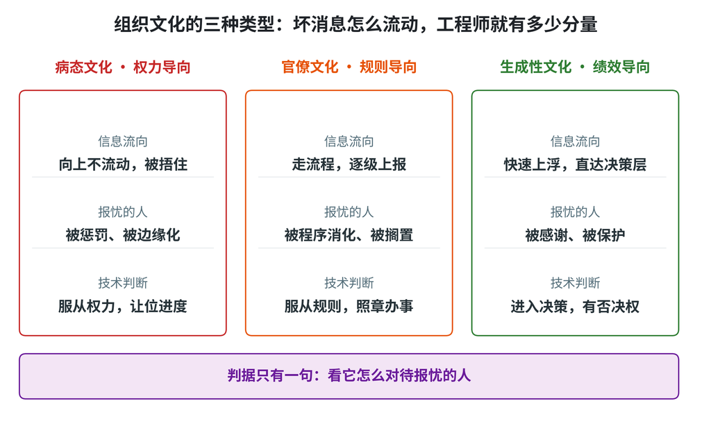

- **是什么**：组织文化是“**看世界的滤镜**”，决定坏消息怎么流动
- **为什么**：同样的工程师，在三种文化里能做的事不同
- **怎么判断**（三问）：
  - 报忧的人**被奖励还是被惩罚**
  - 技术判断是**输入还是执行**
  - 安全质量能不能**压过财务指标**
- 韦斯特鲁姆：病态→官僚→生成性；戴维斯：工程→顾客→财务
- 一句话：**看它怎么对待报忧的人**

## 忠诚的边界：对雇主忠诚，还是对公众负责

- 忠诚有三种对象：雇主、职业、公众
- 准则的排序：公众安全第一，忠实代理第二
- **批判性忠诚**：给雇主应有的利益，但不越过个人与职业伦理
- **盲目忠诚**：把雇主定义的利益放在一切之上
- 盲目忠诚的三种表现：替组织隐瞒、替上级背锅、替错误找理由
- 边界三条：违法行为、危及公众、要求说谎——到此为止
- 忠诚的对象是组织的**目的**，不是某个人的面子
- 一句话：**忠诚不是服从某个人，而是守住角色承诺的义务**

## 案例：阀门 A 与阀门 B

- 情境：工程师 Johnson 为化学装置选阀门
  - **阀门 B**：由经理的朋友销售，不满足最低规格；历史上曾导致多起死亡事故；价格便宜
  - **阀门 A**：最新产品，关闭更快、紧急情况下更少故障；贵 **5%**，公司完全承受得起
- 问题：她该选哪个？如果经理坚持选 B，怎么办？
- 分析：阀门 A 是质量与安全上**清晰无争议**的选择；5% 的差价相对于事故后果可以忽略
- 行动路径：书面技术比较 → 指出 B 的历史事故 → 提出 A 的采购建议 → 若被否决，按 NSPE II.1.a 上报
- 伦理要点：**利益冲突必须披露**；**安全不能靠“人情”打折**

## 不服从的阶梯：六级行动与留证

- 组织不服从：对组织政策或行动的抗议与拒绝
- 三类：相反行动、不参与、抗议（吹哨是最强的一种）
- 阶梯一：内部口头异议——成本最低，先做
- 阶梯二：书面异议——把风险、依据、建议写清楚
- 阶梯三：拒绝执行——基于专业或良知的非参与
- 阶梯四：内部举报——绕过直接上级，走合规或安全通道
- 阶梯五：外部举报——监管、行业组织、媒体
- 阶梯六：辞职并公开——最后手段，代价最大
- 一句话：**每上一级，正当性门槛更高，证据要求也更高**

## 吹哨的证成条件：防害论与共谋论

- 德乔治（防害论）：吹哨是为了阻止对公众的严重伤害
- 可允许的三条：危害严重且相当、已向直接上级报告、已穷尽内部渠道
- 构成义务再加两条：有能说服公正观察者的证据、公开确实能阻止伤害
- 戴维斯（共谋论）：吹哨是为了不让自己成为错误的共谋
- 核心差异：前者问“能不能阻止”，后者问“我是不是帮凶”

| 维度 | 德乔治：防害论 | 戴维斯：共谋论 |
| --- | --- | --- |
| 出发点 | 阻止对公众的伤害 | 避免参与不道德行为 |
| 内部渠道 | 必须先走完 | 不必先走 |
| 证据要求 | 需要充分证据 | 只需合理确信 |
| 适用情形 | 灾难尚未发生 | 灾难已发生或无法阻止 |

- 一句话：**两条路都指向同一件事——不能装作不知道**

## 吹哨的程序与代价

- 程序：内部渠道 → 书面记录 → 逐级上报 → 监管机构 → 媒体
- 证据准备：事实、日期、文件、可复核的技术依据
- 方式选择：实名更有力，匿名更安全；内部优先，外部兜底
- 代价清单：解雇、调岗、孤立、行业排斥、诉讼、家庭压力
- 菲茨杰拉德揭发 C-5A 运输机 **23 亿美元**隐蔽超支
- 1969 年被解职，后复职；推动 1978 年文官改革法
- 制度回应：萨班斯法（2002）与多德—弗兰克法（2010）
- 多德—弗兰克法：奖金为罚款额的 10%—30%
- 欧盟 2019/1937 指令：50 人以上企业须设内部渠道
- 一句话：**吹哨人保护制度，是组织诚实度的试纸**

## 利益冲突：定义、情形与处理

- **定义**：工程师的个人利益（财务、亲属、情感、职业前途）与其职业判断义务相冲突，可能影响判断的客观性
- 四种常见情形：
  1. **财务利益**：持股、回扣、佣金、低价“内部认购”
  2. **礼品与招待**：旅游、宴请、免费样机与咨询费
  3. **亲属与兼职**：亲属公司投标、在外兼职与顾问
  4. **评审自己的成果**：既当运动员又当裁判
- 四种处理：**披露**（书面声明）、**回避**（不参与决策）、**剥离**（卖掉股份/退出关系）、**第三方审查**
- 采购案例：工程师选定某品牌铆钉后，对方送来“全程免费的论坛邀请”（有教育价值，也有海滩）——该不该去？
- 关键：即使判断没被影响，接受之后**别人也无法再相信**判断独立

## 保密义务与知识产权的边界

- **保密范围**：雇主的商业与技术信息、客户的图纸与数据、未公开的评审与投标信息
- **三个例外**：法律要求披露；公众安全受到威胁；依准则举报违规
- **离职带走**：一般技能与经验可带走；具体图纸、数据、客户名单、源代码不能带——为雇主做的设计、数据、记录、笔记**所有权归雇主**
- **前雇主/新雇主**：入职前书面披露保密义务；不得用前雇主专有信息为新雇主服务
- **专利与开源**：职务发明归单位；开源许可分宽松（MIT、Apache）与传染（GPL），用前读许可
- **数据归属**：客户提供的设计→客户所有；共同开发→**开工前**约定所有权
- 新问题：MES 工艺参数、训练好的模型权重，离职带走算不算商业秘密？

## 多手问题的三个现场：签字、接口、集体决策

- 现场一：**集体签字**——评审会一圈人签字，出事找不到“决定者”
- 现场二：**接口地带**——设计、工艺、施工三方交界，谁都说“不归我”
- 现场三：**集体决策**——纪要只写“原则同意”，不写谁负责
- 三种现场的共性：责任**无法被证明**，不是不存在
- 破解各补一件东西：签字人、接口责任人、决定 owner
- 判据：问“如果明天出事，第一个被问的人是谁”——答不出就是多手问题

## 责任分配：谁该为集体决策负责

- 四个角色：提议者、审查者、批准者、执行者
- 五个变量：因果贡献、可控制性、可预见性、角色义务、是否获益
- 一条可用的近似：$R_i \propto C_i \cdot K_i$
- $C_i$ 为因果贡献，$K_i$ 为可控制程度；两者都低，责任才低
- 集体决策必须有一个明确的责任人，否则就是集体免责
- 组织责任与个人责任并行：哥伦比亚号调查同时列了物理原因与组织原因
- 落地三件套：签字、评审记录、异议记录
- 一句话：**没有署名的集体决定，等于没有决定**

## 案例：Brad 的图纸

- 情境：Brad 工作第二年，图纸常未经有经验工程师复核就被盖章送承包商；小项目几周内就开工
- 他的担忧：“我担心我会犯一个害死人的错误”
- 教授的判断：他不能继续这样做——他在从事**超出自己资格、且可能危害公众**的工程工作
- Brad 可以做什么：
  - 书面要求复核；请求资深工程师签审
  - 向公司质量负责人报告；拒绝在未经复核的图上署名
  - 必要时向执业登记机构反映
- 教训：**“盖了章”就是“你确认过”**——哪怕章不是你的

## 组织中的伦理纲领与合规体系

- 五个部件：行为准则、伦理委员会、合规官、培训、审计
- 两个通道：举报热线与申诉程序
- 一个闭环：调查、处理、反馈、修订制度
- 合规管底线（不违法），伦理管追求（做对的事）
- 三种纸面合规：准则上墙、培训打卡、审计补材料
- 有效性检验：坏消息能否上来、例外能否被质疑、指标是否含安全
- 国际参照：ISO 37001（反贿赂）、ISO 37301（合规管理）
- 一句话：**体系的价值不在文件厚度，而在它敢不敢碰有权的人**

## 伦理热线与举报保护

- 四条通道：热线、邮箱、监察员、逐级申诉
- 美国核管会的“不同专业意见”程序：工程师可正式登记异议
- 有效的五个条件：独立、可匿名、有反馈、反报复、有数据
- 独立是关键：向被举报人汇报的热线，等于没有热线
- 反报复要可执行：调岗、考核、晋升都纳入保护范围
- 数据要公开：受理量、处理时长、报复投诉量
- 常见失败：热线成了“情绪出口”，问题不进流程
- 一句话：**举报渠道的试纸，是上一个举报人后来怎么样了**

## 领导者的伦理责任：定调、示范、保护异议

- **定调**：把安全写进考核指标，而不是写进标语
- **示范**：领导者自己认错，别人才敢报错
- **保护**：惩罚报复者，比奖励举报者更有效
- 三个具体动作：最后发言、公开感谢报忧者、亲自复盘事故
- 反例：梅森让伦德“摘下工程师的帽子，戴上管理者的帽子”
- 领导者的一句话，可以改变整条决策链
- 领导者的沉默会被解读为同意，领导者的暗示会被执行成命令
- 一句话：**文化不是写在墙上的，是领导者每次选择的结果**

## 案例：Boisjoly 的备忘录与挑战者号

- 1986 年 1 月 28 日，挑战者号升空 **73 秒**后解体
- **7 名**宇航员遇难；直接原因是 O 型圈低温失效
- 1985 年 7 月，Boisjoly 已书面警告 O 型圈问题
- 发射前夜电话会：Thiokol 工程师建议不发射
- 休会 30 分钟后，副总裁伦德被要求“换帽子”，随即改口赞成
- 举证责任被反转：要工程师证明“不能飞”，而不是证明“能飞”
- 事后：Boisjoly 被孤立并离开岗位
- 1988 年获 AAAS 科学自由与责任奖
- 一句话：**个人做对了一切，制度仍然让他失败**

## 案例：哥伦比亚号的组织失效

- 2003 年 2 月 1 日，哥伦比亚号返航解体，**7 名**宇航员遇难
- 起飞 81.7 秒，外贮箱泡沫脱落，击穿左翼前缘
- 调查委员会列出两类原因：**物理原因**与**组织原因**
- 组织原因：资源约束、进度压力、把航天飞机当成“运营”而非“研制”
- 偏差正常化：多次泡沫撞击未出事，于是被当成可接受风险
- 举证责任再次反转：“证明哥伦比亚号没有被损坏”
- 工程师罗查的警告被搁置，管理层未申请国防部影像
- 一句话：**17 年后，同一套组织条件重演了同一类事故**

## 案例：大众排放门与组织性造假

- 2015 年 9 月 18 日，美国环保署发出违规通知
- 柴油车装了减效装置：识别到检测工况才启用完整排放控制
- 涉及全球约 **1100 万辆**柴油车，氮氧化物最高超标约 **40 倍**
- 美国民事和解 **147 亿美元**，刑事认罚 **43 亿美元**
- 工程师梁某 2017 年被判 **40 个月**监禁
- 组织机制：市场目标 → 技术做不到 → 用软件造假 → 合规外壳掩盖
- 不是几个坏人，而是**目标与手段断裂后无人喊停**
- 一句话：**当指标不可达，造假就会被工程化**

## 案例：波音 737 MAX 的组织压力

- 2018 年 10 月 29 日狮航坠毁，**189 人**遇难
- 2019 年 3 月 10 日埃航坠毁，**157 人**遇难
- MCAS 依据单一迎角传感器反复压机头，飞行员起初并不知情
- 2020 年 9 月美国众议院调查报告的五条主线：
- 生产压力（对标空客 A320neo）、错误的设计假设、**隐瞒文化**
- 利益冲突的“授权代表”制度、监管被企业影响
- 内部试飞数据显示飞行员需 **10 秒以上**才能改出，而假定为 **4 秒**
- 2021 年 1 月，波音与司法部达成 **25 亿美元**和解
- 一句话：**监管外包给被监管者，等于取消了监管**

## 组织伦理的改进路径：从英雄到制度

- 文化层：领导定调、奖励早报告、把安全写进指标
- 流程层：独立评审、异议记录、变更管理、无过错报告
- 权力层：安全职能独立、有一票否决、直接向董事会报告
- 外部层：监管、标准、认证、举报保护、媒体与司法
- 四条共同原则：可核查、可追溯、可异议、可纠错
- 优先级：先改“让说真话变便宜”的制度，再谈道德教育
- 反面教训：每次事故后都加一条规定，却不改权力结构
- 一句话：**好的制度让普通人不必当英雄**

## 项目管理中的伦理：时间—成本—质量三角

- **铁三角**：时间、成本、质量（范围）不可同时最优，任何一项让步都必须**显式记录**
- 赶工压力的四条红线：① 压缩试验周期（用“经验”替代验证）② 绕过变更评审（先改后补、口头同意）③ 降低检验频次（抽检改免检）④ 用估算替代计算
- 现实教训：**反科学抢工**（两年压到一年）、招投标行贿、审核走形式、维护不到位
- 项目伦理检查表（五问）：
  1. 关键试验被压缩了吗？依据是什么？
  2. 变更经过独立评审了吗？谁签的字？
  3. 进度压力被记录并上报了吗？
  4. 安全费用被挪用了吗？
  5. 交付文件里有“已知但未解决”清单吗？

## 本部分小结：组织如何改写判断

- 角色：工程师同时对雇主、职业、公众、法律负责
- 结构：官僚制把责任切碎，流程能证明做过，不能证明做对
- 群体：从众、极化、群体思维，让“一致”取代“正确”
- 权威：米尔格拉姆说明服从是默认设置，距离削弱责任感
- 忠诚：批判性忠诚有边界，越界即不服从
- 不服从：非参与、抗议、吹哨，逐级升高，逐级留证
- 多手：责任可按贡献与可控性分摊，但不能分摊到零
- 建设：文化、流程、权力、外部监督四层同时改
- 一句话：**组织不是伦理的反面，而是伦理的实施现场**

## 推导留给 AI：工程师与组织（汇总）

- 用 Jackall 的六种表现，逐一对照一个你熟悉组织的做法，指出哪几条正在发生。
- 功能性理性有没有“正确用法”？请给出一个“组织目标与工程判断一致”的例子。
- 吹哨的三个条件中，哪一条最容易被组织用来阻止吹哨？为什么？
- 如果你是 Brad，写一份 200 字的书面复核请求（要包含事实、风险、请求三部分）。

## 本部分复习与练习

- 概念：区分从众、极化、群体思维，各举一个工程场景
- 判断：某工程师会上未反对、会后私下抱怨，他违反了哪条义务
- 情境：领导要求“先发货、后补评审”，写出你的三步应对
- 分析：用多手问题框架，给一起集体决策事故分配责任
- 写作：为所在团队设计一条“异议可执行”的评审规则（200 字）
- 讨论：吹哨的代价该由谁承担——个人、组织还是社会
- 延伸：读教材第 7 章，比较德乔治与戴维斯两种证成
- 自测：能否用一句话说清“为什么组织里没人负责”

# 第四部分 · 健康组织文化与信任

- 健康文化的检验标准：上一次坏消息怎么被处理
- 八条做法：通道、态度、程序三组
- 信任的构成：能力、诚实、善意
- 信任的建立与修复：从记录到制度改造

## 信任的定义：能力、善意、诚实

- 信任：**在无法完全监督时，愿意让自己处于脆弱境地的意愿**
- 出处：Mayer 等（1995）的组织信任模型；它不是感觉，是**风险判断**
- 三个维度对应三种托付：任务看能力、底线看善意、信息看诚实
- 三个维度**不能互相补偿**：能力再强，隐瞒一次就归零

| 维度 | 回答的问题 | 可观察证据 | 崩塌方式 |
| --- | --- | --- | --- |
| 能力 | 他做得到吗 | 履历、复核记录、事故率 | 一次力不胜任的签字 |
| 善意 | 他为我考虑吗 | 主动提醒、让利、担责 | 把风险转嫁给我 |
| 诚实 | 他说的是真的吗 | 数据可追溯、承认错误 | 一次隐瞒或改数 |

- 信任的对象可以是个人、团队、组织，也可以是**制度**
- 三个维度也是三次压力测试：给难活、给利益、给坏消息
- 组织里的信任是**双向**的：上级信下级敢报，下级信上级不甩锅
- 一句话：**信任不是好感，是三个维度长期都对得上**

## 信任在工程中的三重作用

- 工程是**多人、多组织、长周期**的合作，合同写不全的缝隙靠信任补
- 信任的替代品是监督，监督的代价是时间、人力与摩擦
- **降低交易成本**：少一层复核、少一轮谈判、快一次决策

| 作用 | 典型场景 | 信任缺失的代价 |
| --- | --- | --- |
| 降成本 | 甲方不必逐项复核 | 层层审批、工期拉长 |
| 促合作 | 设计、总包、分包、供应商接口 | 界面打架、责任推诿 |
| 保报告 | 隐患与近失主动上报 | 瞒报、同类事故重演 |

- **合作基础**：接口多、变更频的项目，靠信任启动第一次协作
- **安全前提**：只有信“报了不被罚”，坏消息才上得来
- 供应链协同里，信任决定信息共享的深度
- 三重作用里，**保报告**最容易被低估，也最致命
- 一句话：**信任是组织里最便宜的协调机制**

## 信任的不对称：建得慢，塌得快

- 建立靠**长期一致**：一次次说到做到，以年计
- 破坏只要**一次**：一次隐瞒、一次甩锅、一次改数
- 三个原因：
  - 负面信息**权重更高**，坏事的记忆比好事更久
  - 隐瞒**证明的是动机**：不是忘了说，而是选择不说
  - 信任一降，**监督立刻增加**，关系进入下行螺旋
- 三类破坏，修复难度递增：能力失误＜善意失误＜诚实失误
- 破坏之后，对方先判断的不是事实，而是“你还值不值得信”

| 阶段 | 时间尺度 | 关键动作 |
| --- | --- | --- |
| 建立 | 数月到数年 | 一致、履约、主动披露 |
| 破坏 | 一次事件 | 隐瞒、甩锅、造假 |
| 修复 | 数倍于建立 | 认错、补偿、改造、监督 |

- 一句话：**信任像瓷器，修补的痕迹永远在**

## 组织信任的四个来源

- 员工对组织的信任，不是对老板的好感，是对**四套机制**的判断
- 四个来源对应四问：规则算不算数、领导扛不扛事、同事帮不帮忙、客户认不认账

| 来源 | 信任依据 | 典型失效 | 可核查证据 |
| --- | --- | --- | --- |
| 制度 | 规则稳定、执行一致 | 朝令夕改、选择性执法 | 制度文本、处理记录 |
| 领导 | 言行一致、出事担责 | 口号安全、出事甩锅 | 到场率、问责记录 |
| 同事 | 能力认可、互惠互助 | 抢功推责、信息垄断 | 协作记录、交接质量 |
| 客户 | 履约、透明、不转嫁风险 | 隐瞒缺陷、夸大能力 | 履约率、投诉处理 |

- 四个来源**互相支撑**：制度塌了，领导再好也留不住人
- **客户信任是结果**：前三个做好了，第四个自然来
- 招聘与晋升是最强的信任信号：提拔谁，就是在说组织信什么
- 四个来源都会老化：制度需复审、领导会更替、同事会流动
- 一句话：**信任不是喊出来的，是四处都能被验证出来的**

## 八条（二）：对事不对人、落实到文字、保密原则

3. **批评：对事不对人**：批评方案、数据、流程，不评价人格与动机
4. **批评：落实到文字**：口头批评无法追溯，也容易被误解；书面记录保护双方
5. **批评：保密原则**：批评内容限定在必要范围，不做“公开处刑”
- 三条的关系：**对事（内容）→ 落文字（形式）→ 保密（范围）**
- 与第 8 讲 NSPE II.3.a 的对应：报告客观、真实、注明日期——组织内批评同理
- 反例：会上不点名批评、会后到处说——最破坏信任
- 落地动作：复盘会纪要“对事记录 + 责任人 + 时限”，不发群、不传播

## 八条（三）：第三方、保护弱者、快速处理

6. **公平的第三方**：争议由中立的第三方裁决（质量部门、安全委员会、外部专家）
7. **保护弱者**：保护资历浅、职位低、承担风险的人（如 Brad）
8. **快速处理**：坏消息必须快速响应；拖延本身就是二次伤害
- 三条的共同点：把“个人对抗组织”变成“程序处理问题”
- 落地动作：安全委员会 + 匿名渠道 + 明确时限（如 48 小时响应、7 天闭环）
- 与 8D 的接口：D3 临时遏制（先止血）、D7 预防再发（制度改造）
- 一句话：**制度的作用，是让普通人也能说真话**

## 八条怎么运转：从“批评”到可核查的制度

- 把八条变成一张**可核查的清单**：有没有、上次使用时间、处理结果、是否闭环
- 与准则的接口：NSPE II.1.a（判断被否决 → 通知主管机关）、II.1.f（报告违规）
- 与 8D 的接口：D3 临时遏制、D5 永久措施、D7 预防再发
- 与信息系统的接口：匿名报告入口、事件台账、闭环时限、复盘记录
- 三个必备要素：**渠道**（能进）、**保护**（敢进）、**闭环**（进了有用）
- 一句话：**文化 = 制度 + 记录 + 复盘的循环**

## 组织文化自检：六个问题

| 维度 | 自检问题 | 健康信号 |
| --- | --- | --- |
| 信息 | 坏消息多久能到一把手？ | 24 小时内、报忧者不受罚 |
| 信息 | 上一次报忧的人后来怎样？ | 被感谢或被保护 |
| 决策 | 技术判断在哪一步进入？ | 方案形成阶段就有否决权 |
| 决策 | 谁对结论签字负责？ | 每份结论有唯一责任人 |
| 激励 | 上一次隐患，谁被奖励？ | 主动上报者被表扬 |
| 激励 | 提拔的是“会办事”还是“敢报忧”？ | 敢报忧的人有上升通道 |

- 三个维度对应三种文化：病态看权力、官僚看规则、生成性看绩效
- 判据：六问里“健康信号”少于三条，文化就还在病态或官僚一端

## 安全文化的三根支柱

- Reason 认为：安全文化不是“不出事”，而是**说得出、判得公、学得会**
- 三根支柱各管一段：

| 支柱 | 回答的问题 | 制度载体 |
| --- | --- | --- |
| 报告文化 | 出了事敢不敢说 | 匿名渠道、无责报告 |
| 公正文化 | 说了会不会被罚 | 行为分类、调查程序 |
| 学习文化 | 说了有没有用 | 复盘、整改闭环、共享 |

- 顺序不能颠倒：没有公正，报告会枯竭；没有学习，报告会白报
- 第四根是**弹性文化**：非常时期能切换组织形态，靠前三根支撑
- 反例：只讲“零事故”的组织，往往把事故赶到地下
- 三根支柱都要落到**可检查的动作**，否则只是口号
- 一句话：**报告是入口，公正是闸门，学习是出口**

## 高可靠性组织的五个特征

- HRO：核电站、空管、航母——**不是没事故，而是对意外保持警觉**
- Weick 与 Sutcliffe 的五条，不是清单，是**注意力的分配方式**

| 特征 | 含义 | 工程做法 |
| --- | --- | --- |
| 关注失败 | 盯近失与异常，不只盯成绩 | 近失台账、异常上报奖励 |
| 拒绝简化 | 不用旧框架套新问题 | 多专业评审、红队复核 |
| 敏感于运行 | 一线动态最先知道 | 班前会、现场走查、值班日志 |
| 坚守韧性 | 出事能顶住、能恢复 | 冗余、演练、应急授权 |
| 尊重专长 | 决策跟着知识走 | 专家呼叫权、越级上报 |

- 共同点：**把意外当常态，把确认当习惯**
- 与八条的关系：HRO 是“让坏消息上来”在安全领域的操作化
- 五条之间互相补位：一条弱，另外四条能兜住
- 反例：把“零事故”当目标，会把异常藏起来
- 一句话：**可靠不是不出错，是出错也接得住**

## 安全文化怎么量、怎么改

- 两类指标：**结果指标**（事故率、损失工时）与**过程指标**（报告率、闭环时长）
- 结果指标的致命缺陷：数字好看，可能是瞒报的结果
- 四个可用的过程指标：
  - 主动报告人数与近失报告数
  - 报告到闭环的中位时长
  - 重复事故占比：同类问题是否再发
  - 安全氛围调查中“敢报”一项的得分
- 改进闭环：测→找最弱一环→改一个制度→再测
- 陷阱：把报告数当 KPI 压下去，会催生凑数报告与瞒报
- 一句话：**量文化，要量“说真话的成本”，不是量事故数**

## 公正文化：差错、风险行为与鲁莽

- 公正文化的核心（Reason）：**追究责任，但不惩罚诚实**
- 三类行为，三种回应：

| 行为类型 | 典型情形 | 回应 | 目的 |
| --- | --- | --- | --- |
| 人为差错 | 疲劳、疏忽、看错 | 安慰＋改系统 | 让人敢报 |
| 风险行为 | 为赶工省一步 | 辅导＋纠偏 | 改判断 |
| 鲁莽行为 | 明知故犯、违章指挥 | 纪律处分 | 守住底线 |

- “不惩罚报告者”≠“不追究责任”：**报告免责，行为照查**
- 公正文化的前提是**事实清楚**：先查清，再分类
- 判断关键：当时知道什么、有没有选择、后果是否可预见
- 反例：一出事就罚最后一个操作者，等于教所有人闭嘴
- 一句话：**公正文化让好人不必完美，让违规无处藏身**

## 学习文化：把事故变成改动

- 学习的标志不是“写了报告”，而是**下一次的行为变了**
- 复盘四问（AAR，行动后复盘）：预期什么→实际什么→为何有差异→下次改什么
- 四个机制：

| 机制 | 做什么 | 产出 |
| --- | --- | --- |
| 独立调查 | 调查权与责任方分离 | 可复核的事实 |
| 近失学习 | 没伤人的事件也要查 | 提前消除隐患 |
| 知识入库 | 经验变检查表、规程、案例 | 组织记忆 |
| 横向推广 | 一个厂区的教训全集团共享 | 不重复交学费 |

- 与 8D 的接口：D4 根因、D5 永久措施、D7 预防再发
- 复盘要产出**可执行的改动**：改图纸、改规程、改培训
- 学习文化要防止“报告疲劳”：只查要改的，不查无关的
- 学习失败的两个原因：**归因于个人**、**归因于天灾**
- 一句话：**事故的第二次代价，是不学习**

## 医院与航空：两种安全文化

- 两个行业都高风险、都靠团队，差异在**报告与问责的制度设计**

| 维度 | 航空 | 医院 |
| --- | --- | --- |
| 报告 | 强制事件报告＋自愿匿名系统（ASRS） | 以自愿上报为主，科内病例讨论 |
| 调查 | 独立机构主导（如 NTSB），对事不对人 | 院内质控与外部评审并行，常回到个人 |
| 标准化 | 检查单、机组资源管理、静默驾驶舱 | 手术安全核查表（WHO，2009） |
| 等级 | 机长负责，副驾有“必须说”的义务 | 主刀权威强，低年资者开口成本高 |
| 问责 | 系统改进优先，故意违规才追责 | 个人归责倾向强，诉讼文化加剧防御 |

- 共同点：错误不可避免，**系统的防线必须冗余**
- 医院的优势在专业判断，短板在**跨专业协作**
- 航空的独立调查机构，是“对事不对人”的制度保障
- 航空的经验：把“说出来”变成**程序义务**，而不是个人勇气
- 医院在补课：核查表易学，**权力距离难改**
- 一句话：**安全文化的差距，差在制度，不差在道德**

## 伦理纲领怎么定才有用

- 伦理纲领（Code of Conduct）：把价值观翻译成**可执行的行为边界**
- 四个要素：**原则**（信什么）、**行为**（做什么）、**案例**（灰区怎么判）、**后果**（违反怎么办）
- 制定过程决定成败：
  - **参与式起草**：一线工程师参与，不请人代写
  - **场景化**：用本公司真实灰区案例，不用抽象口号
  - **培训与签署**：每年一次，签“读过并理解”
  - **年度复审**：法规、业务、案例都在变
- 边界：企业纲领**不得低于**法律与职业准则，只能更严
- 失效的典型：**墙上有、心里无**——Enron 的准则写得很漂亮
- 一句话：**纲领不是道德宣言，是决策的操作系统**

## 合规体系与伦理体系的分工

- 合规回答“**能不能做**”，伦理回答“**该不该做**”
- 合规是底线，靠外部监管驱动；伦理是上限，靠价值驱动

| 维度 | 合规体系 | 伦理体系 |
| --- | --- | --- |
| 驱动 | 法律、监管、罚则 | 价值观、职业准则、声誉 |
| 方法 | 制度、审计、培训、处罚 | 审议、案例、领导示范 |
| 度量 | 罚单、整改率、审计发现 | 报告率、信任度、决策质量 |
| 失效 | 钻空子、形式主义 | 冷漠、真话被压制 |

- 只有合规：**合法但不正当**的事会越来越多
- 只有伦理：没有牙齿，遇到硬约束就退让
- 好的结构：**合规托底、伦理定向**，两条线在董事会汇合
- 两套体系共用一套事实，但用不同问题过滤
- 一句话：**合规让你不被罚，伦理让你被信任**

## 举报保护：法律与公司政策

- 举报只有在**保护到位**时才可能发生；否则理性选择是沉默
- 法律层：
  - 美国：《虚假申报法》（1863）、《吹哨人保护法》（1989）、多德—弗兰克法案（2010）
  - 欧盟：《举报人保护指令》（2019/1937），要求内部渠道与反报复
  - 中国：《安全生产法》（2021）赋予从业人员检举控告、拒绝违章指挥的权利
- 公司层：匿名热线、反报复条款、独立调查、向审计委员会直报
- 有效性的四个条件：**渠道可信、身份保密、报复必究、结果有反馈**
- 现实差距：我国尚无专门的举报人保护法，举证难、职业代价高
- 一句话：**保护举报人，就是保护组织的预警系统**

## 透明有边界：公开什么、何时公开

- 透明不是“全部公开”，而是**可预期地公开**：说什么、何时说、对谁说
- 四类合理例外：
  - 商业秘密与竞争信息
  - 个人隐私与员工信息
  - 安全敏感信息（安防、网络、工艺参数）
  - 调查进行中的未核实信息
- 例外的三条纪律：**说明理由、设定时限、最小范围**
- 分级披露：内部→监管→受影响方→公众，逐级扩大
- 延迟公开的陷阱：拖成“隐瞒”——**时间表本身就是承诺**
- 与准则的接口：NSPE II.3（公开陈述客观真实）、II.4.a（披露利益冲突）
- 一句话：**透明不是没有秘密，而是没有欺骗**

## 数字信任：数据、算法与平台

- 智能制造把信任从“人—人”扩展到“人—系统—平台”
- **数据**：来源合法、最小必要、可追溯——数据造假比图纸造假更难发现
- **算法**：可解释、可审计、有责任人——黑箱不能成为免责理由
- **平台**：规则透明、申诉可达、责任可追——不能既当运动员又当裁判
- 三个机制：**日志**（发生了什么）、**审计**（谁改了什么）、**救济**（错了怎么赔）
- 制度接口：《数据安全法》《个人信息保护法》（2021）、欧盟《人工智能法案》（2024）
- 新风险：模型漂移、数据污染、自动决策的责任真空
- 一句话：**系统越自动，越要把“可追问”设计进去**

## 信任的建立：四条可操作动作

1. **透明**：主动披露风险、利益冲突、不确定性（NSPE II.4.a）
2. **履约**：答应的事按时做到；做不到提前说
3. **记录**：把承诺与判断写下来，让信任可核查
4. **一致**：公开说的与私下做的一致——“no one is looking”时的行为才是品格
- 建立信任最快的动作：**主动报告一个对自己不利的事实**
- 建立信任最慢的方式：**每次都要别人追问才说**
- 组织层面：把“透明”制度化（例：变更公示、风险台账、审计报告）

## 信任修复：分阶段的做法与判据

- 修复不是一次道歉，而是**有期限、有判据的过程**
- 修复的主体是责任方，不是公关部门

| 阶段 | 时限 | 关键动作 | 完成判据 |
| --- | --- | --- | --- |
| 止损 | 0～72 小时 | 停止伤害、公布已知事实 | 受影响方知情 |
| 调查 | 1～4 周 | 独立调查、责任认定 | 事实可复核 |
| 补偿 | 1～3 个月 | 修复、赔偿、安置 | 损失可计量 |
| 改造 | 3～12 个月 | 制度、流程、培训 | 同类风险受控 |
| 验证 | 1 年以上 | 第三方审计、持续披露 | 监督可退出 |

- 顺序不能跳：没查清就补偿＝花钱买沉默；没改造就验证＝自说自话
- 修复失败的三种情形：**隐瞒事实、重复违规、拒绝外部监督**
- 受害方的参与，是修复是否成立的最终判据
- 与前述“认错—补偿—改造—监督”四步一致，这里补**时限与判据**
- 一句话：**信任修复的终点，是对方不再需要监督你**

## 从组织到个人：一张责任地图

- 四个圈层：**个人**（签章／记录）→ **团队**（复核／批评）→ **组织**（文化／制度）→ **社会**（准则／法律／公众）
- 每层的问题不同：个人怕担责、团队怕冲突、组织怕坏消息、社会怕失控
- 每层的“最小可行动作”：
  - 个人：把判断与请示写成文字
  - 团队：做一次独立复核、开一次对事不对人的复盘
  - 组织：设一条能进、敢进、有闭环的坏消息通道
  - 社会：用准则、执照与法律把信任制度化
- 工程师同时属于四个圈层：任何一层失守，都会传导到个人
- 一句话：**伦理不是一个人的勇敢，而是一套让普通人不必勇敢也能做对的制度**

## 组织伦理成熟度的五个层级

- 一个便于自评的五级框架（教学简化）：看**坏消息的第一反应**

| 层级 | 关注点 | 典型做法 | 信任状态 |
| --- | --- | --- | --- |
| 回避型 | 别出事、别曝光 | 压报告、私了 | 低 |
| 合规型 | 别违规、别被罚 | 制度上墙、应付审计 | 中低 |
| 管理型 | 风险可控 | 风险评估、流程嵌入 | 中 |
| 整合型 | 伦理进入决策 | 伦理委员会、案例审议 | 中高 |
| 价值型 | 做对的事 | 领导示范、长期主义 | 高 |

- 多数企业停在**合规型**，因为它的收益最容易被看见
- 升级的杠杆：**领导问责＋举报保护＋案例复盘**
- 降级的信号：一次危机后只剩“加强审批”
- 五级不是线性升级：一次丑闻可能让组织一夜降级
- 自评三问：坏消息怎么处理、谁被追责、制度改了什么
- 一句话：**成熟度不是不出事，是出事后的反应**

## 本部分小结：信任是设计出来的

- 信任＝**能力 × 善意 × 诚实**，靠记录、履约、一致累积，一次隐瞒归零
- 组织信任四源：制度、领导、同事、客户；**客户信任是结果**
- 安全文化三支柱：**报告、公正、学习**；HRO 五特征是它的操作化
- 公正文化：差错安慰、风险辅导、鲁莽处分——**报告免责，行为照查**
- 制度层：伦理纲领定边界、合规托底、举报保护、透明有时限
- 数字时代：数据可追溯、算法可审计、平台可申诉
- 修复五阶段：止损、调查、补偿、改造、验证；终点是**监督可退出**
- 成熟度：从回避、合规到价值驱动，看坏消息的第一反应
- 一句话：**好的组织让普通人不必当英雄，也能做出可信的选择**
- 下一步：进入例题，把风险、责任与信任放进情境判断

## 推导留给 AI：健康组织文化与信任（汇总）

- 把八条做法逐一对应到具体的制度动作（渠道、时限、责任人），做一张检查表。
- 为什么“无过错报告制度”是八条能否运转的关键？没有它，哪几条会失效？
- 用“能力 × 诚实 × 善意”分析一个你信任的组织，指出它最强与最弱的一项。
- 信任修复的四步中，哪一步最容易被跳过？跳过它会有什么后果？

# 第五部分 · 例题、讨论与 AI 提问

- 例题 1：事故性质判定（四段事实 → 安全事故／责任事故）
- 例题 2：责任分配矩阵（五方主体 × 三个核查点）
- 例题 3：组织情境判断；例题 4：利益冲突情境判断
- 课堂讨论：坏消息该不该报、被孤立的吹哨人

## 真题视角：风险与责任怎么考

- 历年真题中与本讲直接相关的是**第 4 讲的事故树题**（安全类论述）
- 本讲内容常以“分析题背景”出现：事故性质判定、责任分配、组织文化
- **预测题**（分析风格）：某事故中“多人都有责任”，如何判定主要负责人？四问：
  1. 是否存在应尽的注意义务？（预见／告知／检查／纠正）
  2. 谁有最终把关权与签章权？
  3. 谁的行为与结果有因果关系？
  4. 组织是否存在责任模糊化的制度设计？
- 一句话：**责任判定靠证据链，不靠“人多”**

## 例题 1：事故性质判定

| 情形 | 事实 | 判定 |
| --- | --- | --- |
| A | 车间行车吊钩断裂砸伤工人；吊钩超期未检，检验记录缺失 | **责任事故**：设备失管（领导责任第 3 条）+ 证据缺失 |
| B | 台风登陆，塔吊已按规程加固并停止作业，仍被超设计风速吹倒 | **非责任事故**：已尽注意义务，属不可抗力 |
| C | 反应釜超压爆炸；安全阀 3 年未校验，操作规程缺失 | **责任事故**：制度缺失 + 设备失管（第 1、3 条） |
| D | 员工夜班违规跨越护栏进入机器人工作区，被机械臂撞击身亡；公司有培训记录、护栏与联锁完好 | **责任事故**（违章作业）：员工直接责任；若管理无排班／监督漏洞则不追究管理责任 |

- 判定不是“二选一”，而是“**责任在谁、占多少**”
- 每一问都要落到证据：没有证据的“知道”，在调查中不算知道

## 例题 2：责任分配矩阵

**事件**：某工地脚手架整体坍塌，3 人死亡。请按五方主体与三个核查点填表，并判定责任。

| 主体 | ① 方案/设计 | ② 过程/现场 | ③ 验收/检验 | 责任判断 |
| --- | --- | --- | --- | --- |
| 建设单位 | 是否压缩安全费用 | — | — | ？ |
| 设计单位 | 脚手架荷载与支撑设计 | — | — | ？ |
| 施工单位 | 专项施工方案 | 搭设与拆除工序 | 验收记录 | ？ |
| 监理单位 | 方案审查 | 旁站与巡检 | 验收签认 | ？ |
| 设备/材料商 | 架管扣件质量 | — | 检验合格证明 | ？ |

- 判定方法：先找“**应做而未做**”的格子，再判断该格子的责任人
- 结论表述：主责单位 + 次要责任单位 + 直接责任人，并说明依据条款

## 例题 3：组织情境判断

| 情境 | 涉及准则 | 你会做什么 | 留下什么记录 |
| --- | --- | --- | --- |
| 领导要求“这次评审不要写会议记录” | II.3.a／II.1.a；美德：勇气 | 坚持记录，或书面说明不同意的理由 | 会议纪要、异议邮件 |
| 你的图纸未经复核就被盖章送出 | II.2／II.1.b；台信“敬业守分” | 书面要求复核；拒绝署名 | 复核请求、往来邮件 |
| 供应商请客后要求你指定其产品 | II.4.a／II.5 | 披露利益冲突；按技术比较选型 | 利益冲突声明、选型报告 |
| 你怀疑同事的实验数据被“美化” | II.3.a／II.1.f | 先核对原始数据，再向负责人报告 | 数据核对记录、报告 |

- 三件事缺一不可：**说清依据 → 采取行动 → 留下记录**
- 记录不是为了告状，是为了**让事实可核查、让责任可追溯**

## 例题 4：利益冲突情境判断

| 情形 | 事实 | 是否构成利益冲突 | 处理动作 |
| --- | --- | --- | --- |
| A | 你负责采购评审，投标方是你大学室友的公司 | 是（关系利益） | 书面披露 + 回避评审 |
| B | 刚选定供应商，对方送来 3000 元培训会议邀请（含旅游） | 是（礼品招待） | 披露并请示；未获批准则拒绝 |
| C | 你被要求评审自己参与设计的方案 | 是（自评） | 回避，改由第三方评审 |
| D | 你业余为另一家公司做同类产品设计，未告知雇主 | 是（兼职/竞业） | 披露并取得书面同意；查合同与竞业条款 |

- 处理顺序：**识别 → 披露 → 回避/剥离 → 第三方审查 → 记录**
- 评分要点：不只看“有没有被影响”，还要看“**会不会看起来被影响**”
- 记录的价值：日后被质疑时，披露记录是唯一能证明判断独立性的证据

## 课堂讨论与开放问题

**讨论 1**：坏消息该不该第一时间上报？如果上报会导致项目延期、团队被追责，你怎么选？

**讨论 2**：如果你是被孤立的吹哨人（Boisjoly 式），你会坚持多久？需要什么支持才能坚持？

**讨论 3**：用第 8 讲的三框架分析“无过错报告制度”——它为什么在伦理上成立？

**讨论 4（开放）**：设计一条适用于你所在实验室／实习企业的“坏消息通道”，写清渠道、保护、闭环时限。

## 历年真题：本讲（伦理）考查方式与分值

- 六卷＝2020／2021／2022 三届 A／B 卷，满分 100，题型与分值高度稳定
- **直接伦理题 0 分**：六卷没有一道“伦理”题；伦理只能作为背景或论据嵌入
- 与本讲方法直接相关的有 20 分：事故树 10 分、鱼骨图 10 分
- 若新增伦理题，最可能是 10 分论述（“结合案例谈责任”）或 5 分简答（“说明吹哨条件”）
- 复习投入按 10% 计：概念要准、案例要实、判断有依据，不背长篇
- 答题时把伦理当“判据”：先给准则条款，再给事实，最后给判断

| 题型 | 分值 | 与本讲的关系 | 说明 |
| --- | --- | --- | --- |
| 单选 | 30（10×3） | 概念辨识 | 含法人无限责任 3 分 |
| 简答 | 30（6×5） | 判据复述 | 六卷均无伦理题 |
| 事故树 | 10 | 风险评估（FTA） | 割集对应责任点 |
| 鱼骨图 | 10 | 人的因素 | 人机料法环 |
| 其他 | 20 | 邻接矩阵、回收期 | 与本讲无关 |

- 一句话：**伦理不单独计分，但决定论述题的“上限”**

## 计算例题：风险值计算与分级（概率×后果）

- 定义 $R = P \times C$：$P$ 年发生概率，$C$ 单次后果（人数或万元）；单位不同的 $R$ 不能比较或相加
- 5×5 矩阵取 $R=L \times S$：1—4 低、5—9 中、10—15 高、16—25 极高；表中 L、S 为专家打分示例

| # | 场景 | L×S | R（等级） |
| --- | --- | --- | --- |
| 1 | 冲压机光电保护失效 | 4×3 | 12（高） |
| 2 | 锅炉安全阀卡死超压 | 2×5 | 10（高） |
| 3 | 压力管道腐蚀穿孔 | 4×2 | 8（中） |
| 4 | 叉车通道人车混行 | 4×2 | 8（中） |
| 5 | 除尘器粉尘爆炸 | 1×5 | 5（中） |

- 算例：$R=0.2 \times 400=80$ 万元/年，是长期年均期望，不保证今年不出事
- 同一 $R$ 不等价：$4 \times 2$ 与 $2 \times 4$ 同为 8，处置不同；低频高后果要看最大后果
- 矩阵只排序，可接受性还要 ALARP、知情同意与分配正义

## 计算例题：风险控制措施的效果比较

- 同一工位：$p_0=0.20$/年、$C_0=400$ 万元，故 $R_0=80$ 万元/年；降幅 $\eta=(R_0-R_1)/R_0$，投资为一次性

| 措施 | 假设改动 | $R$（降幅）／投资 |
| --- | --- | --- |
| 甲 | 培训＋规程：$p$→0.16 | 64（20%）／5 万元 |
| 乙 | 光栅＋联锁：$p$→0.04、$C$→300 | 12（85%）／60 万元 |
| 丙 | 限速＋力控：$p$→0.10、$C$→200 | 20（75%）／30 万元 |
| 丁 | 物理围栏：$p$→0.01 | 4（95%）／15 万元 |

- 甲是管理措施，乙、丙、丁是工程控制——层级不同，不能只比数字
- 年降额÷投资：丁 5.1、甲 3.2、丙 2.0、乙 1.13——围栏最“划算”，却牺牲协作功能：**降险效果不等于净效益**
- 联锁的 85% 依赖“不被旁路”；可靠性、可验证性要与降幅同评
- 优先级：消除＞替代＞工程控制＞管理控制＞个体防护；组合措施不能相乘（屏障失效相关）

## 案例论述：挑战者号的组织伦理分析（示范）

**题目（10 分）**：结合挑战者号事故，论述工程师的异议为何失效、组织应负什么责任。

- 事实：1986-01-28 升空 73 秒爆炸，7 人遇难；SRB 密封圈低温失效
- 事实：密封圈温度边界 53°F→29°F；Boisjoly 1985-07-31 书面警告，管理层要求摘帽后批准发射
- 冲突：安全与进度、声誉；职业判断与管理权威；对雇主忠诚与对公众负责
- 义务论：NSPE I.1 公众安全优先；工程师不得把技术判断让给管理权衡
- 后果论／美德论：7 条生命、航天飞机停飞近三年；诚实与勇气
- 结论：主要责任在组织决策链，工程师个人责任有限但不为零；把责任推给“工程师没坚持”，正是责任模糊化的话术
- 措施：独立安全否决权、异议书面化并限时答复、偏离台账、匿名通道与报复保护
- 得分：事实 2＋冲突 2＋框架 3＋结论 1＋措施 2

## 案例论述：吹哨的证成分析（示范）

**题目（10 分）**：同一案例换个问法——Boisjoly 的行动是否构成被证成的吹哨？

- 事实：发射前书面警告与电话会议反对，事故后向罗杰斯委员会作证

| 框架 | 条件与本案事实 | 判定 |
| --- | --- | --- |
| DeGeorge ①② | 危害严重可预见、已报上级（备忘录） | 满足 |
| DeGeorge ③ | 穷尽内部渠道：未报安全负责人 | 未满足 |
| DeGeorge ④⑤ | 证据可信、公开能阻止伤害：缺低温数据 | 部分 |
| Davis C1—C4 | 自愿、相信严重作恶、工作助长、来自工作 | 满足 |
| Davis C5 C6 | 信念有据；O 形环确是肇因（事后） | 部分／事后 |

- 判定一：按 DeGeorge ③ 未满足、④⑤只部分，严格说未完全证成；紧迫与渠道失效可作例外
- 判定二：按 Davis 不必证明公开一定奏效，避免共谋本身足以证成吹哨
- 合评：内部先走完（DeGeorge），但不必等到“能阻止伤害”才发声（Davis）
- 得分：事实 2＋条件对照 4＋结论 2＋评价 2；事实段只写可核查的

## 课堂讨论：组织压力下工程师能做什么

- 下表五个情境，每组选一个，10 分钟给出“下一步动作＋留痕方式”
- 先分清“压力”与“理由”：压力再大，也不构成技术判断的依据

| 压力类型 | 典型话术 | 可做的动作 |
| --- | --- | --- |
| 进度 | “先发货，下批再补测试” | 要求书面指令；把风险写成一句话邮件 |
| 成本 | “这个传感器太贵，先用便宜的” | 要一份降配后的风险对比；请质量负责人签认 |
| 权威 | “我干了二十年，不用你教” | 用数据说话；请求独立复核；记录会议结论 |
| 同侪 | “大家都签了，你别特殊” | 只对自己签的内容负责；注明“未复核” |
| 身份 | “试用期别惹事” | 找导师或安全员；用匿名通道；保留时间线 |

- 动作按代价排序：留痕 → 要求复核 → 请求书面指令 → 升级 → 拒绝签字 → 举报
- 三个“不要”：不要只口头说、不要替别人签字、不要删掉自己的草稿
- 把“我不同意”改成“我建议这样补测，风险是……”，把立场变成方案
- 讨论产出：一张“压力—动作—证据”三列小表，课后交半页
- 一句话：**能做什么，取决于你把哪一步变成了可核查的记录**

## 课堂讨论：AI 监测与人的责任边界

- 场景：识别未戴护目镜、预测轴承故障、预警气体泄漏——AI 报警、人处置；三类失效：漏报（最危险）、误报（告警疲劳）、漂移（上线后变差）

| 环节 | AI 做什么 | 人保留什么 | 责任落点 |
| --- | --- | --- | --- |
| 开发 | 训练模型、声明指标 | 定义“可接受漏报率” | 开发者：性能与适用范围 |
| 部署 | 设阈值、做场景适配 | 验收测试、试运行 | 部署者：场景失配 |
| 运行 | 实时告警、排序 | 复核、现场确认 | 值班人：响应与处置 |
| 漂移 | 性能随数据下降 | 监控、定期复评 | 管理者：再验证制度 |
| 事故 | 提供日志 | 停机、救援、报告 | 组织：不得以“算法”免责 |

- 三种责任：角色（该你做）、因果（你造成）、法律（可追偿）——人在回路要时间、信息、权限，否则只是“背锅位”
- 责任随谁控制、谁受益、谁可预见分配；三张日志：告警、处置、复核签字——缺一条，责任就断
- 讨论：AI 漏报致伤，操作员、部署方、开发者各担什么？谁有权关掉误报？
- 一句话：**AI 可以报警，但不能签字；责任不能外包给算法**

## 课堂辩论：安全投入的边界在哪里

- **辩题**：本厂已符合法规，是否还应再投 300 万元，把某工位年事故概率从 2% 降到 1%？
- 设每次事故损失 500 万元；300 万元按 10 年摊，年成本 30 万元

| 立场 | 主张 | 依据 |
| --- | --- | --- |
| 正方 | 合规即可，边际收益太低 | 年省 5 万元，投入 30 万元/年 |
| 反方 | 重大伤害不能只算期望值 | 灾难不可逆；ALARP；非自愿风险 |
| 裁决 | 先划“不可接受区”，再比选 | 法规底线；ALARP；知情同意 |

- 算一遍：$R_0=0.02 \times 500=10$ 万元/年，$R_1=5$ 万元/年，只省 5 万元/年
- 纯算术结论是“不值”，但成本效益有四条边界：效果算不全、生命难定价、分配被忽略、无知情同意
- ALARP：除非降险成本与收益“严重不成比例”，否则继续降；灾难性风险不适用纯 CBA
- 辩论规则：每方 3 分钟立论／2 分钟质询／1 分钟总结；结论写清谁承担风险
- 一句话：边界不是一条线，是“不可接受区—ALARP 区—可接受区”三段

## 简答模板：风险／组织／信任各答三段

- 三段不是三个段落，是三个得分动作：首句给判断，第二句给依据，第三句给动作

| 题型 | 三段 | 关键词 | 收尾句 |
| --- | --- | --- | --- |
| 风险 | 识别→评估→控制 | 来源、$P \times C$、分级、残余 | 先分级，再按层级控制，最后沟通 |
| 组织 | 情境→机制→行动 | 压力、责任模糊化、渠道 | 制度不改，个人再勇也撑不住 |
| 信任 | 构成→证据→修复 | 能力／诚实／善意、记录、四步 | 信任靠履约累积，靠制度修复 |

- 风险题必写单位与分级依据；组织题必写“谁、在哪一步、留下什么”
- 信任题必写“可核查的证据”：履约记录、披露记录、第三方监督
- 每段留一个“证据位”：数据、条款、记录，阅卷按这三样给分
- 反面：只写“加强管理”“提高意识”——没有主体、没有动作、没有记录
- 时间：5 分题 6—8 分钟，10 分题 15 分钟；先列三段提纲再写
- 一句话：**模板不是填空，是逼你把“感觉”翻译成“证据”**

## AI 提问：本讲 5 个延伸问题

- 把课堂结论变成可验证的问题：给数据、要复算、追问反例

| 主题 | 让 AI 做什么 | 追问与核对 |
| --- | --- | --- |
| FTA | 为“协作机器人伤人”建树、求最小割集 | 基本事件概率从哪来？有历史数据吗？ |
| ALARP | 比较 ALARP 与成本效益在我国的适用 | 引《安全生产法》原文；核对条款号 |
| 角色 | 扮演“要求摘帽”的经理，与你对话 | 复盘哪句话是压力、哪句话是理由 |
| 漏报 | 列 AI 监测漏报的 5 类原因 | 每类给一个可做的验证试验 |
| 吹哨 | 生成证据清单与时间线模板 | 哪些证据可能违法获取？边界在哪？ |

- 五问对应五块：风险分析、可接受风险、组织压力、AI 监测、吹哨
- 提问三件套：给定数据／要求复算／追问反例；AI 的答案只是初稿
- 核对纪律：来源要能打开、条款要核原文、数字要能手算
- 把 AI 的回答改写成 300 字提纲，标注哪些是事实、哪些是推断
- 小组互评：谁的问题能被第三方复现，谁就得分
- 一句话：**会提问，比会背答案更接近工程师的工作方式**

## 考前自测：10 道判断题

- 先独立判断，再看括号里的答案；错 3 题以上，回到对应页重读
1. 风险值相同，两种风险就可同等对待。（×：还看后果分布）
2. 风险矩阵可以直接替代 ALARP。（×：矩阵只排序）
3. 安全联锁属于工程控制措施。（√）
4. 安全培训主要降低事故后果。（×：主要降概率）
5. 残余风险可以降到零。（×：只能降到可接受）
6. 书面记录能让口头指令可核查。（√）
7. 上级口头批准后，签字人不再负责。（×：签字即责任）
8. 吹哨前必须走完全部内部渠道。（×：紧迫可例外）
9. AI 报警后，责任转移给供应商。（×：责任不转移）
10. 信任修复的第一步是补偿。（×：先认错）

## 本讲错题回顾与订正

- 错题不是“再看一遍”，是找到“哪一步想错了”

| # | 典型错误 | 错因与订正 |
| --- | --- | --- |
| 1 | $R$ 相同就认为风险相同 | 忽略后果分布与单位；订正：报 $P$、$C$、$R$ 三件套 |
| 2 | 合规就等于尽责 | 法规是底线；订正：合规＋ALARP＋知情同意 |
| 3 | 集体决定可以免责 | 责任随签章与把关权；订正：找“应做而未做”的格子 |
| 4 | 吹哨是第一反应 | 未走内部、无证据；订正：阶梯＋证据链＋时限 |
| 5 | AI 报警后责任归算法 | 责任不能转移；订正：人保留复核与停机权 |
| 6 | 信任修复先谈赔偿 | 没认错，补偿像“花钱了事”；订正：先认错 |

- 错题本三栏：原题／错因（概念、证据、程序）／订正一句话
- 同一错误连错两次，说明是概念问题，回去重读对应页
- 订正要写“下次遇到同类题，我先做什么”
- 错题按“概念／证据／程序”分类，比按题型分类更有用
- 考前只看错题本与三张模板，不再刷新题
- 一句话：**错题的价值，在于暴露你默认的那条错误假设**

# 第六部分 · 本讲小结、作业与下讲预告

## 本讲小结：风险、组织、信任三句话

1. **风险**：风险是概率与后果的乘积，可接受风险是价值判断而非计算结果；技术因素可计算、人为因素可管理、外部环境要留退路——**没有零风险，只有安全等级**。
2. **组织**：事故定性看“应尽而未尽的注意义务”，组织却用功能性理性、群体思维与责任模糊化把义务消解掉；**责任判定靠证据链，不靠“人多”**。
3. **信任**：信任是能力、诚实与善意的乘积，靠记录与履约累积；坏消息能上来、异议有出口，组织才能长期可靠。
- 一条主线：风险怎么来 → 事故怎么定性 → 组织怎么让人做不到 → 制度怎么改
- 一个判据：能说清“谁受影响、受多大、凭什么”，才叫伦理判断
- 一句衔接：第 8 讲给“应该”，本讲给“为什么做不到”，第 10 讲给“怎么改”

## 关键概念清单：20 个术语

| 组 | 4 个术语 | 一句话 |
| --- | --- | --- |
| 风险与度量 | 风险＝概率×后果、可接受风险、故障树 FTA、事件树 ETA | 风险定“多大” |
| 事故与定性 | 安全事故、安全责任事故、注意义务、领导责任五情形 | 事故定“谁的责任” |
| 组织与判断 | 功能性理性、群体思维、责任模糊化、多手问题 | 组织定“为什么做不到” |
| 行动与选择 | 职业矛盾、利益冲突、吹哨三条件、不服从阶梯 | 行动定“怎么做” |
| 文化与信任 | 批判性的忠诚、无过错报告、能力×诚实×善意、信任修复四步 | 信任定“能不能持续” |

- 会辨析三对：安全事故／安全责任事故、职业矛盾／交流矛盾、责任模糊化／多手问题
- 会算两式：$R=p\times C$；与门（独立）$P(T)=P(A)P(B)$
- 抽查：下次课随机抽 5 个术语，各配一句定义与一个本讲事实

## 作业：概念、案例与风险计算（100 分）

**一、概念（20 分）**：20 个术语任选 10 个，各写一句定义＋一个本讲事实（10 分）；辨析安全事故／安全责任事故、职业矛盾／交流矛盾（各 5 分）。

**二、案例分析（45 分）**：选甬温线 7·23 或凤凰沱江大桥，按四问逐条给证据（20 分）；画一条从技术触发到管理定性的责任链（15 分）；指出一条责任模糊化的制度设计（10 分）。

**三、风险计算（35 分）**：顶事件为“安全阀失效且超压”：记失效为 $A$、超压为 $B$，两者独立，$P(A)=2\times10^{-3}$、$P(B)=5\times10^{-2}$。求顶事件年概率（10 分）；阈值 $10^{-5}$ 下 $P(A)$ 的上限（10 分）；两条整改措施各降低哪一项（15 分）。

- 计算写公式与代入；概率用科学计数法，单位写“每年”
- 提交 A4 或 PDF，下次课前；案例须注明调查报告或判决书来源
- 评分：事实具体（时间／部位／数字）＋依据可查（条款／公式）＋方案可执行

## 下讲预告：技术的社会意义、全球工程与 AI 伦理

| 内容块 | 主题 | 核心内容 | 关键问题 |
| --- | --- | --- | --- |
| 1 | 技术的社会意义 | 内嵌、决定论、环境伦理 | 技术路线由谁选 |
| 2 | 工程国际化 | 三大协定、四个守则组织 | 相对主义有底线吗 |
| 3 | AI 伦理 | 偏见、隐私、可解释、问责 | 模型错了谁负责 |
| 4 | 智能设计与课程设计 | 视觉、GNN、振源识别 | 你的项目风险在哪 |

- 第 10 讲 2 课时（伦理部分 1 课时），是伦理专题收尾：从“组织内”走到“社会与全球”，再落到 AI 与课程设计
- 预习：把判定四问与信任三要素套到你毕设的一个部件或算法上，各写一条
- 带一个问题来：你的项目如果出错，最坏后果是什么、谁有权叫停？

## 课后阅读与预习清单（Harris 第 6、7 章）

| 章节 | 主要内容 | 页码与读法 |
| --- | --- | --- |
| 第 6 章 | 风险定义、可接受性、公众沟通与侵权 | p107–135；精读 §6.2、§6.5 |
| 第 7 章 | 群体思维、组织文化、不服从与吹哨 | p138–169；精读 §7.4、§7.6 |
| 第 4 章（预习） | 技术内嵌于社会、决定论与批判态度 | p72–88；通读，备第 10 讲 |

- 中文材料：《工程与社会》课件“工程中的风险、安全与责任”“个人与组织的关系”两讲
- 选读：第 5 章 Trust and Reliability（p90–106），补诚实与保密的英文表述
- 读法：先读案例再回正文；§7.11 Boisjoly 与本讲挑战者号页对照读
- 提交：1 页笔记（每章 1 条要点＋1 个疑问）；预习问题：上次坏消息怎么上来的？

## 伦理案例写作要求：六段结构与评分

课程设计伦理章按六段写，每段先给判断、再给证据。

| 段落 | 要求 | 证据 |
| --- | --- | --- |
| ① 事实 | 时间、部位、数字、来源 | 调查报告或判决书 |
| ② 问题 | 归入五类伦理问题 | 准则或法规条款 |
| ③ 分析 | 三框架各给一条推理 | 数据、公式、先例 |
| ④ 方案 | 两个备选并说明取舍 | 成本与风险比较 |
| ⑤ 反驳 | 最强反对意见与回应 | 反例、边界条件 |
| ⑥ 结论 | 条件、监测、责任人 | 可核查的指标 |

- 篇幅 1500 字以内；动笔前先按三步框架列利益相关方，再进六段
- 评分只看三件事：事实能否核查、判断有无依据、方案是否回应了最强反对
- 三条红线：不编造情节、不只批评不给方案、不把“合规”当成“无过错”

## 期末复习：案例论述题的给分点

| 环节 | 具体要求 | 本讲素材 | 常见失分 |
| --- | --- | --- | --- |
| 事实 | 时间、部位、数字 | 7·23：40 死 172 伤 | 只写“管理混乱” |
| 定性 | 四问逐条判断 | 设备缺陷＋审查不严 | 凭后果定性 |
| 依据 | 条款、准则或公式 | NSPE 准则、调查报告 | 堆术语不落地 |
| 方案 | 两个备选与代价 | 独立复核、冗余设计 | 只批评不给方案 |
| 表达 | 结论有条件 | 责任链与签章 | 结论绝对化 |

- 时间分配：事实 5 分钟、定性 4 分钟、依据 5 分钟、方案 4 分钟、表达 2 分钟
- 真正给分的只有四条：事实具体、依据可查、方案可执行、结论有条件；定性是这四条的前提
- 自测：用这五点口述“甬温线事故中谁该负责”，限时 3 分钟

## 本讲重点回顾与考试提示

**四个必须能复述**

1. 风险量与阈值：$R=p\times C$、与门（独立）$P(T)=P(A)P(B)$；可接受风险是价值判断
2. 判定四问：可预见？义务尽了？违章？管理到位？——证据决定定性
3. 责任模糊化六条与健康文化八条：前者让证据链断裂，后者让坏消息能上来
4. 信任三要素与修复四步：能力×诚实×善意；认错—补偿—制度改造—监督

**三句可直接引用**

- 没有零风险，只有可接受风险。
- 后果大小不决定定性，义务缺失才决定定性。
- 制度的作用，是让普通人不必勇敢也能做对。

考试提示：先给事实（时间、部位、数字），再给判断，最后给依据；判断与依据之间用“因为”连起来，不写感想、不堆术语。